# 第二章：数据处理 与 探索性数据分析

章节作者：刘贇喆 | 华东师范大学 社会发展学院

更新时间：2026-10-10

章节概述

本章讨论社会科学数据进入分析前需要完成的基本工作。第一部分区分 R 对象的类型、类与结构，并用变量、观测和取值解释整洁数据。随后以 `tidyverse` 为主要工具，练习选择行列、重命名变量、构造变量、分组汇总、连接表格和长宽转换；每项操作都配有输入、输出与结果检查。

数据处理还包括质量诊断。缺失值、重复记录、文本格式和列名需要依据数据字典与研究设计处理，不能只以代码能否运行为标准。最后一部分使用数据概览、描述统计、分组比较和相关分析检查分布、异常记录与变量关系，并区分描述性结果、探索性线索与因果解释。

# **本章学习内容**

## **学习导航**

**本章学习内容**

下方 6 张导航卡对应本章的主要学习单元。

**阅读提示**：通过返回主页或主页按钮，可回到本章学习导航。

## **1.0 数据类型与结构**

### **1.0 数据类型与结构**

R 中的每个对象都有类型和结构。类型说明值如何存储，结构说明这些值如何组合。读懂这两层信息，才能判断一段代码为什么能够计算，或为什么会报错。

#### **1.1 常用数据类型**

R 把数值、文本和逻辑值保存在对象中。数据类型（data type）描述对象在内存中的基本存储方式；对象类（class）则告诉 R 应采用哪一组方法处理该对象。`typeof()` 和 `class()` 因此可能返回不同结果。

R 中常见底层类型、适用值与 `typeof()` 结果

| **常用类型** | **适合保存的值** | **示例** | `typeof()` |
| --- | --- | --- | --- |
| `logical` | 逻辑判断结果 | `TRUE`、`FALSE` | `"logical"` |
| `integer` | 明确写成整数的数值 | `23L`、`-3L` | `"integer"` |
| `double` | R 中常见的数值 | `23`、`3.14` | `"double"` |
| `character` | 文本、编码和标签 | `"上海"`、`"A01"` | `"character"` |

普通数字 `23` 的对象类是 `numeric`，底层类型是 `double`；在数字后加 `L` 得到整数 `23L`。这属于存储差异，不能直接用来判断社会科学变量是离散变量还是连续变量。

将下列代码保存在项目脚本 `scripts/01_objects.R` 中，可从上到下逐行运行并比较输出。

```r
score <- 23
student_count <- 23L
city <- "上海"
completed <- TRUE

class(score)
```

```
##  [1] "numeric"
```

```r
typeof(score)
```

```
##  [1] "double"
```

```r
class(student_count)
```

```
##  [1] "integer"
```

```r
typeof(student_count)
```

```
##  [1] "integer"
```

#### **常见问题：数字被读成文本**

引号中的 `"13"` 是字符值，不能直接参与加法。Excel 或 CSV 的某一列混入单位、空格或文字时，也可能被导入为字符型。

```r
response <- "13"
class(response)
```

```
## [1] "character"
```

此时运行 `response + 2` 会报错，因为加法要求数值输入。确认 `"13"` 确实表示数字后，再创建转换后的新对象。

```r
response_num <- as.numeric(response)
response_num + 2
```

```
## [1] 15
```

先检查原始值，再进行转换。直接覆盖原对象可能掩盖录入错误或特殊编码。

**进阶了解：转换失败、`NA` 与缺失值检查**

`as.numeric()` 只能转换可以识别的数字文本。无法识别的值会产生 warning，并转换为缺失值 `NA`。

```r
raw_response <- c("13", "未回答")
numeric_response <- as.numeric(raw_response)
is.na(numeric_response)
```

`is.na()` 会逐个判断元素是否缺失。此处只需认识 `NA`；缺失原因和处理方法将在 4.0 集中讨论。

#### **1.2 核心数据结构**

数据结构（data structure）描述多个值怎样组合成一个对象。选择结构时主要看三个问题：对象有几维、各元素能否使用不同类型，以及后续需要按位置还是按名称提取。

常见 R 数据结构的维度、类型规则与提取方式

| **对象** | **维度** | **类型规则** | **常用提取** |
| --- | --- | --- | --- |
| 向量（vector） | 一维 | 元素使用同一种原子类型 | `[ ]` |
| 列表（list） | 一维 | 成员可以使用不同类型和结构 | `[[ ]]` / `$` |
| 矩阵（matrix） | 二维 | 单元格使用同一种原子类型 | `[行, 列]` |
| 因子（factor） | 一维 | 分类标签由 `levels` 保存 | `[ ]` / `levels()` |
| 数据框（data frame） / `tibble` | 二维 | 各列等长；列与列的类型可以不同 | `[[ ]]` / `$` / `[行, 列]` |

常用创建函数包括 `c()`、`list()`、`matrix()`、`factor()`、`data.frame()` 和 `tibble::tibble()`。原子向量只能使用一种类型，例如 `c(13, "未回答")` 会形成字符向量。`[ ]` 可以按位置、名称或逻辑条件保留一个或多个元素；`[[ ]]` 从列表或数据框中取出一个成员；`$` 也可按名称提取，例如 `student_data$city`，但名称必须直接写在代码中。

交互式代码观察

##### 对象与结构检查器

切换对象，比较相同检查函数在不同结构上的返回结果。

R 代码

```
score_vec <- c(
  72, 88, 91
)
score_vec[2]
```

**`typeof()`**

double

**`class()`**

numeric

**规模**

长度 3；没有二维维度

**提取结果**

`88`

向量中的三个元素都按双精度数值存储。

**进阶了解：数组与因子的底层表示**

数组（array）把同一种原子类型排列到两个以上的维度中；矩阵可以看作二维数组。课程后续主要处理表格数据，因此只需能够识别数组。

```r
score_array <- array(1:8, dim = c(2, 2, 2))
score_array[1, 2, 2]

region_factor <- factor(c("东部", "西部", "东部"))
levels(region_factor)
unclass(region_factor)
```

因子在底层使用整数编码，并用 `levels` 保存显示标签。分析时应根据标签和水平顺序解释因子，不应把底层整数当作可直接计算的测量值。

#### **1.3 读懂表格数据**

社会科学数据常以行和列组成表格。在 R 中，常见表格对象是 `data.frame` 和 `tibble`。`tibble` 继承 `data.frame`，主要改进打印方式和部分子集操作的行为；两者都由等长列组成。

#### **案例数据：Gapminder**

`gapminder` 包提供同名的 `gapminder` 数据对象，整理了 Gapminder 项目的历史国家数据。该表包含 1,704 条记录和 6 个变量，涉及 142 个国家、5 个大洲和 12 个年份。

**时间范围**

1952—2007 年，每 5 年一次

**观测单位**

一个国家在一个年份

**指标单位**

`lifeExp` 为出生时预期寿命（年），`pop` 为人口，`gdpPercap` 为人均 GDP

**使用边界**

历史教学样本，不能描述各国当前状况

其余两列是国家 `country` 和大洲 `continent`。字段名来自数据包原表，本章沿用 `lifeExp` 和 `gdpPercap` 等原名。

##### **1.3.1 加载数据与阅读 tibble**

`library(gapminder)` 在当前 R 会话中加载包；随后输入 `gapminder`，即可预览同名数据对象。代码块关闭包加载消息和 warning，使网页只保留数据输出。在 Console 中运行时，仍可能看到与本机包版本有关的提示。

```r
library(gapminder)
gapminder
```

```
  # A tibble: 1,704 × 6
     country     continent  year lifeExp      pop gdpPercap
     <fct>       <fct>     <int>   <dbl>    <int>     <dbl>
   1 Afghanistan Asia       1952    28.8  8425333      779.
   2 Afghanistan Asia       1957    30.3  9240934      821.
   3 Afghanistan Asia       1962    32.0 10267083      853.
   4 Afghanistan Asia       1967    34.0 11537966      836.
   5 Afghanistan Asia       1972    36.1 13079460      740.
   6 Afghanistan Asia       1977    38.4 14880372      786.
   7 Afghanistan Asia       1982    39.9 12881816      978.
   8 Afghanistan Asia       1987    40.8 13867957      852.
   9 Afghanistan Asia       1992    41.7 16317921      649.
  10 Afghanistan Asia       1997    41.8 22227415      635.
  # ℹ 1,694 more rows
```

##### **读懂控制台输出**

**`# A tibble: 1,704 × 6`**

对象有 1,704 行、6 列。

**`<fct> <int> <dbl>`**

列名下方显示各列的对象类或底层类型缩写。

**`ℹ 1,694 more rows`**

当前只打印前 10 行，其余记录仍保存在对象中。

`<int>` 与 `<dbl>` 描述存储方式。变量是计数、年份还是连续测量值，仍由数据含义决定。

`tibble` 在 R Console 中会根据可用宽度显示适量的行和列，因此打印行数可能随设置变化。Knit 写入网页后，打印结果保留生成时的排版。需要明确控制预览范围时，可使用 `head()` 或 `print(n = ...)`。

##### **生成 HTML 表格**

Knit 会在独立的 R 会话中按顺序运行代码，并把结果写入 HTML。`knitr::kable()` 可将数据框转为适合网页阅读的表格。

```r
knitr::kable(
  head(gapminder, 3),
  caption = "Gapminder 数据集前 3 行",
  digits = 1
)
```

Gapminder 数据集前 3 行

| country | continent | year | lifeExp | pop | gdpPercap |
| --- | --- | --- | --- | --- | --- |
| Afghanistan | Asia | 1952 | 28.8 | 8425333 | 779.4 |
| Afghanistan | Asia | 1957 | 30.3 | 9240934 | 820.9 |
| Afghanistan | Asia | 1962 | 32.0 | 10267083 | 853.1 |

`digits = 1` 控制数值列的显示精度，不会改写 `gapminder` 对象中的原始值。

##### **1.3.2 行、列与观测单位**

`gapminder` 中的观测、变量与数值

| **表格要素** | **含义** | **在 `gapminder` 中的对应内容** |
| --- | --- | --- |
| 数据集（dataset） | 围绕同一主题组织的整张表 | 整个 `gapminder` 表 |
| 变量（variable） | 描述某项属性的一列 | `country`、`year`、`lifeExp` 等 |
| 观测（observation） | 表中的一行记录 | 某国某年的一组指标 |
| 观测单位（unit of observation） | 一行对应的对象与情境 | 国家 × 年份 |

`country` 和 `year` 共同定位一条记录。只看 `country` 会遗漏时间差异，只看 `year` 会混合多个国家。确认观测单位后，才能判断重复记录、缺失值和汇总结果是否合理。

##### **1.3.3 初步检查数据**

初次读取一张表时，可依次检查规模、列名、对象类、列结构、首尾记录和缺失情况。下面的代码都使用已经加载的 `gapminder` 对象，可以直接运行。

```r
dim(gapminder)       # 行数与列数
names(gapminder)     # 列名
class(gapminder)     # 对象类
str(gapminder)       # 各列结构与部分取值
head(gapminder)      # 前 6 行
tail(gapminder)      # 后 6 行
anyNA(gapminder)     # 是否存在 NA
```

`str()` 把对象类、维度和逐列信息集中显示，适合第一次检查数据。

```r
str(gapminder)
```

```
  tibble [1,704 × 6] (S3: tbl_df/tbl/data.frame)
   $ country  : Factor w/ 142 levels "Afghanistan",..: 1 1 1 1 1 1 1 1 1 1 ...
   $ continent: Factor w/ 5 levels "Africa","Americas",..: 3 3 3 3 3 3 3 3 3 3 ...
   $ year     : int [1:1704] 1952 1957 1962 1967 1972 1977 1982 1987 1992 1997 ...
   $ lifeExp  : num [1:1704] 28.8 30.3 32 34 36.1 ...
   $ pop      : int [1:1704] 8425333 9240934 10267083 11537966 13079460 14880372 12881816 13867957 16317921 22227415 ...
   $ gdpPercap: num [1:1704] 779 821 853 836 740 ...
```

tibble 控制台输出符号的读取方法

| **输出片段** | **读取方法** |
| --- | --- |
| `tibble [1,704 × 6] (S3: tbl_df/tbl/data.frame)` | 1,704 行、6 列；兼容 `data.frame` |
| `$ country : Factor w/ 142 levels ...` | `country` 是含 142 个水平的因子列 |
| `$ year : int [1:1704] 1952 1957 ...` | `year` 以整数存储，共 1,704 个值 |

`anyNA(gapminder)` 返回 `FALSE`，表示这张表没有 `NA`。这项检查只能回答“是否出现缺失值”，不能说明样本是否完整或数据是否具有代表性。

**进阶了解：S3 类标签与传统 data.frame**

`class(gapminder)` 返回 `tbl_df`、`tbl` 和 `data.frame` 三个类标签。R 会按顺序寻找适用的方法，这使 tibble 能保留数据框兼容性，同时使用自己的打印和子集行为。

```r
class(gapminder)
class(as.data.frame(gapminder))
```

暂时只需记住：`class()` 可能返回多个标签，排在前面的类通常决定更具体的处理方式。

#### **1.4 小节自测**

选择答案后点击“检查答案”，页面会显示对应解析。

01对普通数字 `23` 分别运行 `class()` 和 `typeof()`，会得到什么？ `integer` 与 `integer` `numeric` 与 `double` `double` 与 `numeric`

02下面哪项准确描述了数据框？ 所有单元格必须使用同一种类型 每一列可以有不同长度 各列长度相同，不同列可以使用不同类型

03`gapminder` 中一行数据的观测单位是什么？ 一个国家在一个年份 一个国家的全部年份 一个年份的全部国家

**课外阅读与函数文档**

下面四个页面分别对应本节的类型、对象类、tibble 和案例数据。无法联网时，可在 Console 中运行 `?typeof`、`?class` 或 `vignette("tibble", package = "tibble")` 查看本地帮助。

[**R：typeof()**底层类型与返回值↗](https://stat.ethz.ch/R-manual/R-patched/library/base/html/typeof.html) [**R：class()**对象类与方法分派↗](https://stat.ethz.ch/R-manual/R-patched/library/base/html/class.html) [**tibble 入门**打印、创建与子集操作↗](https://tibble.tidyverse.org/articles/tibble.html) [**gapminder**CRAN 包页面与参考手册↗](https://cran.r-project.org/package=gapminder)

## **2.0 整洁数据**

### **2.0 整洁数据**

**整洁数据**（tidy data）是一套组织数据的约定：让**变量、观测和取值**在表格中各有明确的位置，便于理解、分析与复核。

调查问卷、业务记录和统计报表常按不同方式保存。面对同类分析任务，研究者因而需要反复辨认和调整数据结构。Hadley Wickham 在 2014 年发表的 *Tidy Data* 中系统阐述了整洁数据框架，目的是通过**一致的数据结构**减少重复整理，让数据处理、建模和可视化工具更容易衔接（[Wickham，2014](https://www.jstatsoft.org/article/view/v059i10)）。

#### **2.1 概念与规则**

整洁性取决于**数据的含义与表格结构是否对应**。理解规则之前，需要先区分三个概念：变量（variable）记录某一种属性，观测（observation）记录研究对象在指定条件下的情况，取值（value）则是某条观测在某个变量上的具体内容。

例如，研究两座城市的公共图书馆使用情况，可以把“一座城市在一个年份的记录”定义为一条观测。下表包含城市、年份、到馆人次三个变量，共有四条观测；到馆人次以**万人次**计，数值均为教学模拟数据。

**在同一张表中辨认三个概念**

两市公共图书馆年度到馆人次（模拟数据）

| 城市 | 年份 | 到馆人次（万人次） |
| --- | --- | --- |
| A 市 | 2019 | 120 |
| A 市 | 2020 | 110 |
| B 市 | 2019 | 95 |
| B 市 | 2020 | 90 |

**每个变量各占一列**

变量表示记录的某一种属性。“到馆人次”这一列只记录到馆人次，各行使用相同的计量单位；城市和年份分别放在另外两列。列中的数值可以不同，但含义应一致。

**每条观测各占一行**

本例的一条观测是一座城市在一个年份的记录。最后一行把“B 市”“2020 年”和“90 万人次”放在一起。B 市在 2019 年的记录属于另一条观测，因此城市名称可以在不同的行中重复。

**每个单元格保存一个值**

取值是某条观测在某个变量上的具体内容。右下角的“90”表示 B 市 2020 年的到馆人次。它的含义需要结合所在行、列名和计量单位一起理解；数字和城市名称都可以是取值。

这三条表内规则采用 [*R for Data Science* 的表述](https://r4ds.hadley.nz/data-tidy.html)。Wickham（2014）还强调，**每类观测单位各成一张表**。例如，图书馆基本信息可以每馆一行，城市年度统计则每个城市每年一行；两类记录分别保存，并注明城市等关联信息。

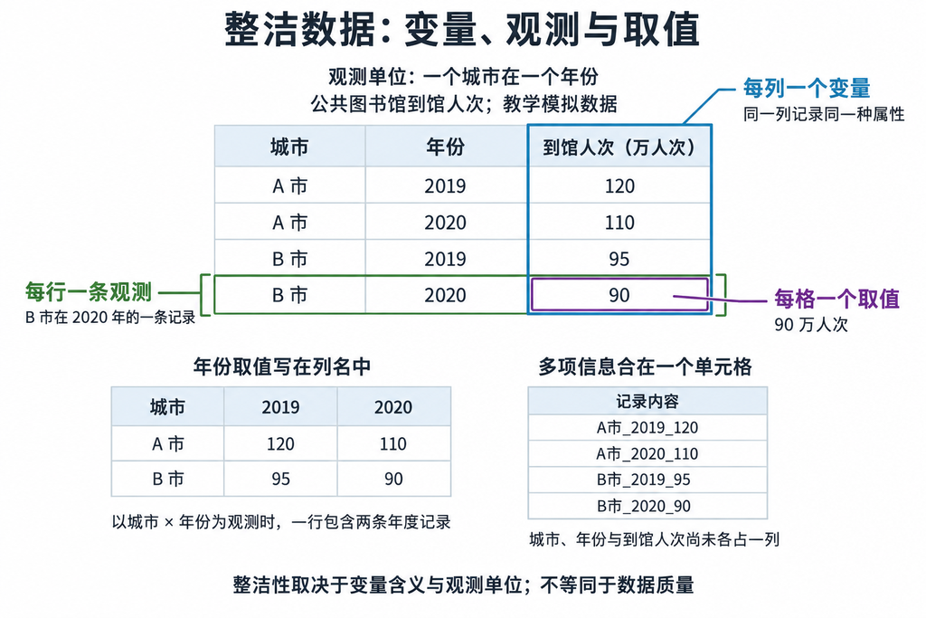

整洁数据中变量、观测与单元格的对应关系

#### **2.2 常见排法**

**先明确变量的含义和观测单位，再判断排法。** 行列数量、表格外观或单元格颜色，都不足以单独判断数据是否整洁。

##### **年份写入列名**

下面仍是两座城市的四个年度数值，每行把同一城市的两年数据并列展示。

按年份并列展示到馆人次（万人次，模拟数据）

| 城市 | 2019 | 2020 |
| --- | --- | --- |
| A 市 | 120 | 110 |
| B 市 | 95 | 90 |

在“每个城市每年一条观测”的约定下，年份本身是一个变量。这里把年份的取值写进列名，一行便包含了两条年度观测。与前面的四行表相比，数值没有改变，**变量和观测所处的位置改变了**。

**宽表一定不整洁吗？**

宽表便于并排阅读，是否整洁仍取决于各列的含义。若一人只测量一次，身高和体重是两个不同的变量，适合各占一列；它们的单位分别为厘米和千克。将各年数值排在多列，与把身高、体重排在两列，需要分别判断。

##### **多个变量合存**

如果 `F_23` 约定表示“女性、23 岁”，同一个单元格就同时记录了性别与年龄。只记录 `F_23`，无法直接从某一列读出所有人的年龄；把性别与年龄作为两个变量记录，含义会更清楚。这里 `F` 的含义依赖编码说明，不能仅凭字母猜测。

**日期时间也包含多个变量吗？**

时间戳（timestamp）如 `2025-04-29 19:03:52` 表示一个时间点，可以作为一个变量的取值。字符串里有空格或符号，并不意味着一个单元格包含多个变量；需要依据记录的含义判断。

##### **观测单位混排**

若一行表示一名学生的成绩，就应按这一约定理解所有数据行。下表最后一行代表整个小组，与前两行的个人记录不同。

个人记录与小组汇总混排（模拟数据）

| 小组 | 学生 | 记录含义 | 成绩 |
| --- | --- | --- | --- |
| G1 | A01 | 个人成绩 | 82 |
| G1 | A02 | 个人成绩 | 74 |
| G1 | 不对应个人 | 小组均值 | 78 |

这张表包含两名学生和一条小组汇总，不能按三名学生理解。个人记录与小组统计分别成表，有助于保持每张表中观测单位的一致性。若只在个人表中附加一列“所在小组均值”，一行仍对应一名学生，与混入小组汇总行的情况不同。

#### **2.3 用途与边界**

一致的数据结构使分析任务更容易对应到明确的变量和观测。在城市年度案例中，这种对应关系体现在：

**便于比较**

比较 2019 年与 2020 年时，年份列标明各条记录所属的时间。

**便于分析**

城市、年份和到馆人次各有明确位置，筛选、汇总与绘图可以围绕同一套变量展开。

**便于复核**

通过“B 市、2020 年”定位到同一条记录，再核对其到馆人次是否为 90 万人次。

**整洁结构与数据质量需要分别检查**

表格符合整洁规则，仍可能存在缺失值、重复记录或错误数值。例如，同一个城市同一年出现两条重复记录，或到馆人次被误填为负数，行列外观依然可以十分规整。整洁规则说明如何组织数据，数值是否可信还需要结合来源、计量单位与调查过程判断。

**借助 AI 识读表格时，需要说明什么？**

可以同时提供观测单位、变量含义与计量单位。例如：“每行是一座城市某一年的记录，到馆人次以万人次计。”这些说明可作为核对 AI 解释的依据。整洁结构不能保证 AI 正确理解变量，更不能替代对原始记录的核验；涉及个人信息时，应先按数据使用要求处理，避免上传可识别个人的记录。

#### **2.4 小节自测**

01本例中，B 市 2019 年和 2020 年的记录应如何理解？ 城市相同，因此只能算一条观测 年份不同，分别对应两条城市年度观测 只有到馆人次不同，才算两条观测

02关于整洁数据，下列哪项理解正确？ 所有宽表都不符合整洁规则 符合整洁规则，就说明所有数值都正确 需要结合变量含义与观测单位判断行列安排

**概念来源与延伸阅读**

- [Wickham, H.（2014）. *Tidy Data*. Journal of Statistical Software, 59(10), 1–23.](https://www.jstatsoft.org/article/view/v059i10) 原始论文，重点阅读数据结构与语义、变量、观测单位的讨论。
- [*R for Data Science*：Data tidying](https://r4ds.hadley.nz/data-tidy.html)。开头的 “Tidy data” 部分用表格说明列、行与单元格规则。
- [tidyr：Tidy data](https://tidyr.tidyverse.org/articles/tidy-data.html)。重点阅读 “Data semantics” 和 “Tidy data”，比较不同表格排法的含义。以上均为英文材料。

## **3.0 tidyverse 操作**

### **3.0 tidyverse 操作**

#### **3.1 tidyverse 与数据准备**

**tidyverse 是一组为数据分析设计的 R 包。** 这些包采用相近的写法，分别承担数据读取、整理、计算和绘图等任务。对于表格数据，常见操作包括选择行列、计算新变量、分组汇总和关联多张表。

`tidyverse` 也指统一安装和加载这组核心包的入口包。运行 `library(tidyverse)` 后，常用函数便可在当前 R 会话中调用。本节重点使用 `dplyr` 和 `tidyr`：

本节使用的 tidyverse 核心包及其分工

| 包 | 在数据分析中的作用 | 本节中的例子 |
| --- | --- | --- |
| **dplyr** | 选择行列、计算变量、分组与连接 | `filter()`、`mutate()`、`summarise()` |
| **tidyr** | 调整变量与观测在表中的排列 | `pivot_longer()`、`separate_wider_delim()` |
| **tibble** | 创建和显示数据表 | `tibble()` |
| **readr** | 读取文件和解析数值 | `parse_integer()` |

核心包还包括 `ggplot2`、`purrr`、`stringr`、`forcats` 和 `lubridate`。它们的分工见 [tidyverse 官方包说明](https://www.tidyverse.org/packages/)。加载包不要求立即掌握其中全部函数，先围绕具体的数据任务选择工具。

##### **准备练习数据**

下列示例使用 `gapminder`：每行记录一个国家或地区在某年的出生时预期寿命、人口和人均 GDP。数据覆盖 1952—2007 年，每五年一期。`lifeExp` 与 `gdpPercap` 是数据集的原始列名；练习副本将其改为 `life_exp` 与 `gdp_per_cap`，便于统一命名。

```r
library(tidyverse)
library(gapminder)

# 保留原始列名的数据副本
test_data <- gapminder

# 本节使用的练习副本
practice_data <- test_data %>%
  rename(life_exp = lifeExp, gdp_per_cap = gdpPercap)

head(practice_data, 3)
```

```
# A tibble: 3 × 6
  country     continent  year life_exp      pop gdp_per_cap
  <fct>       <fct>     <int>    <dbl>    <int>       <dbl>
1 Afghanistan Asia       1952     28.8  8425333        779.
2 Afghanistan Asia       1957     30.3  9240934        821.
3 Afghanistan Asia       1962     32.0 10267083        853.
```

**运行准备**：如尚未安装所需包，可在 Console 中运行 `install.packages(c("tidyverse", "gapminder"))`，安装一次即可。每次新建 R 会话仍需运行上方准备代码。直接进入某个函数页面时，也先完成这一步。

在 RStudio 脚本中，Windows 使用 `Ctrl` + `Enter`，macOS 使用 `Cmd` + `Enter` 运行选中代码。结果通常显示在控制台（Console）；`View(practice_data)` 打开的是数据查看器（Data Viewer）。

##### **管道与赋值**

管道符 `%>%` 通常将左侧结果作为右侧函数的**第一个参数**。因此，`practice_data %>% head(3)` 与 `head(practice_data, 3)` 等价。多步操作按从上到下的顺序执行：

```r
data_2007 <- practice_data %>%
  filter(year == 2007) %>%
  select(country, life_exp)

head(data_2007, 3)
```

```
# A tibble: 3 × 2
  country     life_exp
  <fct>          <dbl>
1 Afghanistan     43.8
2 Albania         76.4
3 Algeria         72.3
```

这里先筛选 2007 年的记录，再保留两列，最后通过 `<-` 保存为 `data_2007`。**只运行管道并打印结果，不会改写原对象。** 后面的示例也遵循这一规则。

#### **3.2 常用处理函数**

##### **函数导航**

**从数据任务选择函数**

下面 12 项按行列操作、计算汇总和表格整理排列。每项先给出基础用法；参数交互和折叠区用于观察差异或进一步练习。

**读图约定：** 示意图中的中文字段用于辨认变量含义，正文代码块是可复制、可运行的课程版本。原始列名若含空格、括号等符号，需要使用反引号包围；课程代码继续采用 `snake_case`。

##### **概览：`glimpse()`**

###### **3.2.1 数据概览**

`glimpse()` 将**每个变量放在一行中显示**，依次列出变量名、数据类型和部分取值。打印结果便于检查行列规模、数字是否被存成文本等问题，原数据的行列结构保持不变。

```r
practice_data %>% glimpse()
```

```
Rows: 1,704
Columns: 6
$ country     <fct> "Afghanistan", "Afghanistan", "Afghanistan", "Afghanistan"…
$ continent   <fct> Asia, Asia, Asia, Asia, Asia, Asia, Asia, Asia, Asia, Asia…
$ year        <int> 1952, 1957, 1962, 1967, 1972, 1977, 1982, 1987, 1992, 1997…
$ life_exp    <dbl> 28.801, 30.332, 31.997, 34.020, 36.088, 38.438, 39.854, 40…
$ pop         <int> 8425333, 9240934, 10267083, 11537966, 13079460, 14880372, …
$ gdp_per_cap <dbl> 779.4453, 820.8530, 853.1007, 836.1971, 739.9811, 786.1134…
```

输出开头的 `Rows` 与 `Columns` 分别表示行数和列数。`<int>` 表示整数，`<dbl>` 表示双精度数值，`<fct>` 表示因子。这里只显示部分取值，**不能凭预览认定整列没有缺失或录入错误**。

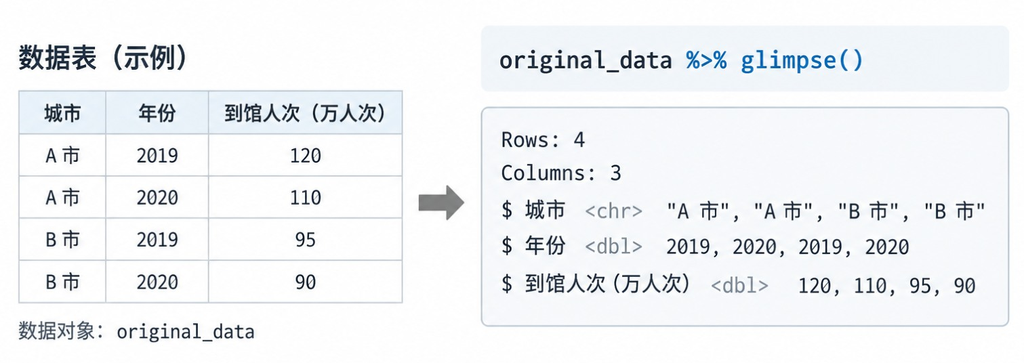

glimpse() 按变量列出名称、类型和部分取值，原表保持不变

##### **选列：`select()`**

###### **3.2.2 变量选择**

`select()` 选择数据的列。按名称列出需要的变量，结果就按给定顺序排列；在列名前加 `-` 可以排除该列。普通未分组数据的行数保持不变。

```r
practice_data %>%
  select(country, year, life_exp) %>%
  head(3)
```

```
# A tibble: 3 × 3
  country      year life_exp
  <fct>       <int>    <dbl>
1 Afghanistan  1952     28.8
2 Afghanistan  1957     30.3
3 Afghanistan  1962     32.0
```

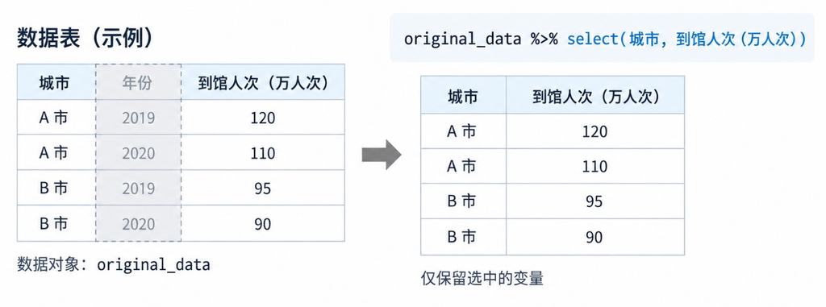

select() 保留城市与到馆人次两列，四条观测保持不变

按列名、前缀和类型选择变量

| 选择方式 | 可运行的写法 |
| --- | --- |
| 排除人口列 | `practice_data %>% select(-pop)` |
| 按前缀选择列 | `practice_data %>% select(starts_with("life"))` |
| 选择数值列 | `practice_data %>% select(where(is.numeric))` |

数值列也可能包含年份或编号。**变量的统计含义仍需单独判断**，不能把数值列全部当作需要求均值的指标。

**选学：必需列、可选列与正则选择**

列名保存在字符向量中时，`all_of()` 要求每一列都存在，适合检查必需变量；`any_of()` 忽略不存在的列，适合选择可选变量。

```r
required_cols <- c("country", "year", "life_exp")
practice_data %>% select(all_of(required_cols)) %>% head(3)
```

```
# A tibble: 3 × 3
  country      year life_exp
  <fct>       <int>    <dbl>
1 Afghanistan  1952     28.8
2 Afghanistan  1957     30.3
3 Afghanistan  1962     32.0
```

```r
optional_cols <- c("life_exp", "pm25_mean")
practice_data %>% select(any_of(optional_cols)) %>% head(3)
```

```
# A tibble: 3 × 1
  life_exp
     <dbl>
1     28.8
2     30.3
3     32.0
```

`matches()` 按正则表达式匹配**列名**。例如，`practice_data %>% select(matches("^life|_cap$"))` 保留以 `life` 开头或以 `_cap` 结尾的列。复杂规则宜先检查匹配到的列名。

按位置写 `select(1:3)` 也可以选择列，但列顺序改变后，结果含义可能随之改变。长期使用的脚本优先写出列名。

##### **列名：`rename()`**

###### **3.2.3 列名与列序**

`rename()` 使用 **`新列名 = 原列名`** 的顺序。`relocate()` 调整列的位置，便于把标识列和相关指标放在一起。两者都不修改单元格中的数值。

```r
renamed_data <- practice_data %>%
  rename(population = pop) %>%
  relocate(year, .after = country)

head(renamed_data, 3)
```

```
# A tibble: 3 × 6
  country      year continent life_exp population gdp_per_cap
  <fct>       <int> <fct>        <dbl>      <int>       <dbl>
1 Afghanistan  1952 Asia          28.8    8425333        779.
2 Afghanistan  1957 Asia          30.3    9240934        821.
3 Afghanistan  1962 Asia          32.0   10267083        853.
```

这里把 `pop` 改为 `population`，并将 `year` 移到 `country` 后面。`.before` 可指定放在哪列之前；省略位置参数时，`relocate()` 将选定列移到最前面。

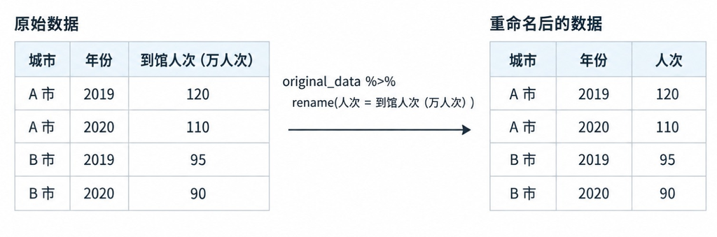

rename() 只改变列名，观测与数值保持不变

改名之后要使用新名称。 `renamed_data` 中人口列叫 `population`；`practice_data` 中仍叫 `pop`，因为结果保存到了另一个对象。

##### **筛选：`filter()`**

###### **3.2.4 条件筛选**

`filter()` 选择数据的行，只保留条件结果为 `TRUE` 的记录。下例同时限定年份和大洲，最后显示前三条结果：

```r
practice_data %>%
  filter(year == 2007, continent == "Europe") %>%
  select(country, year, life_exp) %>%
  head(3)
```

```
# A tibble: 3 × 3
  country  year life_exp
  <fct>   <int>    <dbl>
1 Albania  2007     76.4
2 Austria  2007     79.8
3 Belgium  2007     79.4
```

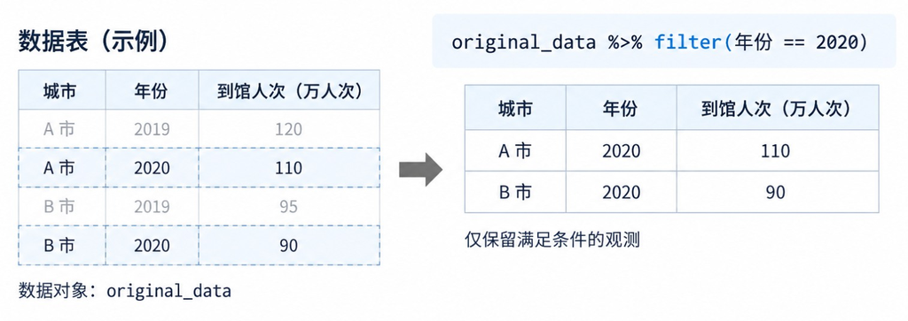

filter() 按条件保留观测，变量列保持不变

filter() 中常用的条件写法

| 目的 | 条件写法 |
| --- | --- |
| 等于、不等于 | `year == 2007`；`year != 2007` |
| 达到某个阈值 | `life_exp >= 75` |
| 同时满足 | `filter(year == 2007, life_exp >= 75)` |
| 满足至少一个 | `filter(year == 2007 \\| life_exp >= 75)` |
| 属于指定类别 | `filter(continent %in% c("Asia", "Europe"))` |
| 位于闭区间 | `filter(between(year, 1997, 2007))`，包含两端 |

表内条件用于 `practice_data %>%` 之后。判断相等使用 `==`；字符取值如 `"Europe"` 需要引号。

交互观察

###### 条件改变后，哪些行被保留？

在同一张成绩表上调整年份、分数和条件组合，观察筛选后的行数。

**查看示例数据**

示例数据：demo_data

| id | group | year | score |
| --- | --- | --- | --- |
| 1 | A | 2020 | 55 |
| 2 | A | 2021 | 70 |
| 3 | B | 2020 | 70 |
| 4 | B | 2021 | 85 |
| 5 | C | 2020 | 85 |
| 6 | C | 2021 | 95 |

年份条件

分数下限

条件组合

```
library(dplyr)

# 教学模拟数据：每行是一名学生的一次成绩记录
demo_data <- tibble::tibble(
  id = 1:6,
  group = c("A", "A", "B", "B", "C", "C"),
  year = c(2020, 2021, 2020, 2021, 2020, 2021),
  score = c(55, 70, 70, 85, 85, 95)
)

demo_data %>%
  filter(year == 2020, score >= 60)
```

当前设置的运行结果

| id | group | year | score |
| --- | --- | --- | --- |
| 3 | B | 2020 | 70 |
| 5 | C | 2020 | 85 |

年份和分数两个条件都为 TRUE 的行才被保留。 结果：2 行 × 4 列。

预览为本页所列设置的 R 计算结果；复制完整代码可在 R 中运行。

条件为 `NA` 的行也不会保留。 `filter(!is.na(life_exp))` 明确删除寿命缺失的记录。若希望保留“寿命至少 75 或寿命缺失”的记录，条件应写为 `life_exp >= 75 | is.na(life_exp)`。缺失值的处理决定需要结合分析目的。

**选学：按文本模式筛选**

`str_detect()` 检查**单元格的文本**是否符合模式。例如：

```r
practice_data %>%
  filter(year == 2007, str_detect(country, "^United")) %>%
  select(country, year)
```

```
# A tibble: 2 × 2
  country         year
  <fct>          <int>
1 United Kingdom  2007
2 United States   2007
```

`^United` 表示以 `United` 开头。这属于模式匹配，不会自动识别拼写错误或同义名称。选择列名的 `matches()` 与检查列内取值的 `str_detect()` 作用位置不同。

##### **排序：`arrange()`**

###### **3.2.5 数据排序**

`arrange()` 默认按升序排列，`desc()` 指定降序。多个排序变量依次生效：先比较第一列，取值相同时再比较下一列。**排序改变行的位置，不会自动生成排名变量。**

```r
sorted_data <- practice_data %>%
  filter(year == 2007) %>%
  arrange(continent, desc(life_exp))

sorted_data %>%
  select(country, continent, life_exp) %>%
  head(5)
```

```
# A tibble: 5 × 3
  country   continent life_exp
  <fct>     <fct>        <dbl>
1 Reunion   Africa        76.4
2 Libya     Africa        74.0
3 Tunisia   Africa        73.9
4 Mauritius Africa        72.8
5 Algeria   Africa        72.3
```

结果先按大洲排列，再在各洲内部按寿命降序排列。`sorted_data` 保存排序后的表；原 `practice_data` 保持不变。

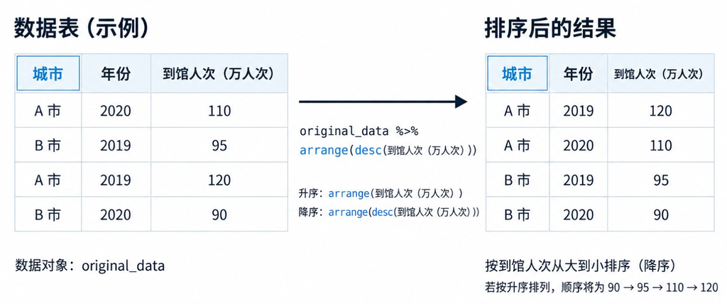

arrange() 按到馆人次降序重排记录，整行数据一起移动

本地数据框中的 `NA` 排在最后，使用 `desc()` 时也如此。字符排序受语言区域设置影响；中文姓名或地区名不宜直接解释为“按拼音顺序”。

##### **取行：`slice_*()`**

###### **3.2.6 取行与抽样**

取出表格开头的记录、取出指标最高的记录和随机抽取记录，分别服务于预览、极值比较和抽样。`slice_*()` 用不同函数区分这些操作。

取行与随机抽样的常用函数

| 函数 | 常用参数 | 含义 |
| --- | --- | --- |
| `slice_head()` | `n = 3` | 按当前顺序取前三行 |
| `slice_max()` | `order_by`、`n`、`with_ties` | 按指定变量取最大值记录 |
| `slice_sample()` | `n` 或 `prop`、`replace` | 随机抽取记录 |

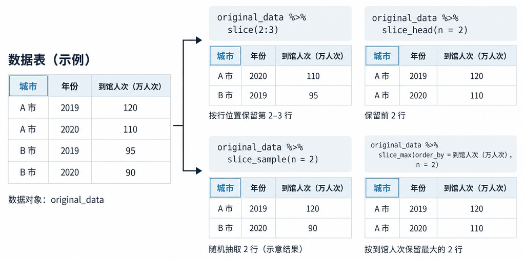

slice 系列函数按行位置、表头位置、指标大小或随机方式取得记录

```r
practice_data %>%
  filter(year == 2007) %>%
  slice_max(order_by = life_exp, n = 3, with_ties = FALSE) %>%
  select(country, life_exp)
```

```
# A tibble: 3 × 2
  country          life_exp
  <fct>               <dbl>
1 Japan                82.6
2 Hong Kong, China     82.2
3 Iceland              81.8
```

`order_by = life_exp` 指定比较依据。`with_ties` 默认是 `TRUE`，边界上的并列值会一并保留；设为 `FALSE` 时至多取指定数量，同分记录按输入顺序选取。

**随机种子（random seed）确定伪随机序列的起点。** `set.seed()` 属于基础 R，通常放在需要复现的随机操作之前：

```r
set.seed(123)

sampled_countries <- practice_data %>%
  filter(year == 2007) %>%
  slice_sample(n = 5, replace = FALSE)

sampled_countries %>% select(country, year, life_exp)
```

```
# A tibble: 5 × 3
  country       year life_exp
  <fct>        <int>    <dbl>
1 Botswana      2007     50.7
2 Greece        2007     79.5
3 South Africa  2007     49.3
4 Ethiopia      2007     52.9
5 Zimbabwe      2007     43.5
```

`replace = FALSE` 是默认值，表示不放回抽样；`TRUE` 允许同一条记录被抽中多次。按比例抽取可写 `slice_sample(prop = 0.2)`，与 `n` 二选一；行数取整时向下舍去不足一行的部分。先限定年份后，一行对应一个国家该年的记录；直接抽取整个数据集，抽到的则是**国家年度记录**。

交互观察

###### 抽取数量、并列值与随机种子

切换抽取方式，比较相同数据在不同设置下的结果。随机模式提供连续 5 次抽取，随后可从头重跑。

**查看示例数据**

示例数据：demo_data

| id | group | year | score |
| --- | --- | --- | --- |
| 1 | A | 2020 | 55 |
| 2 | A | 2021 | 70 |
| 3 | B | 2020 | 70 |
| 4 | B | 2021 | 85 |
| 5 | C | 2020 | 85 |
| 6 | C | 2021 | 95 |

抽取方式

抽取数量或比例n 与 prop 二选一；两者都省略时默认为 1 行。

随机种子从头重跑会重新设置种子。

是否放回默认不放回；放回抽样允许同一条记录重复出现。

保留边界上的并列值默认保留并列值，因此结果可能超过指定行数。

```
library(dplyr)

# 教学模拟数据：每行是一名学生的一次成绩记录
demo_data <- tibble::tibble(
  id = 1:6,
  group = c("A", "A", "B", "B", "C", "C"),
  year = c(2020, 2021, 2020, 2021, 2020, 2021),
  score = c(55, 70, 70, 85, 85, 95)
)

set.seed(123)
demo_data %>%
  slice_sample(n = 3, replace = FALSE)
```

当前设置的运行结果

| id | group | year | score |
| --- | --- | --- | --- |
| 3 | B | 2020 | 70 |
| 6 | C | 2021 | 95 |
| 2 | A | 2021 | 70 |

当前为同一种子起点后的第 1 次抽取。继续抽取会推进随机数状态；从头重跑可复现第 1 次结果。本次抽取中每条记录最多出现一次。 结果：3 行 × 4 列。

预览为本页所列设置的 R 计算结果；复制完整代码可在 R 中运行。抽样预览使用 R 4.6.1、dplyr 1.2.1。随机结果还取决于数据顺序与随机数生成器设置。

**固定起点，复现操作序列。** 在相同数据顺序、代码和随机数设置下，重新运行 `set.seed(123)` 及其后的抽样代码，可以复现结果。只设置一次种子后继续抽取，随机数状态会向前推进，结果通常发生变化。

种子不保证样本具有代表性。研究对象是否被覆盖、抽样方式是否合适，仍需要结合数据来源判断。不同种子也可能偶然抽到相同样本。

**选学：同一种子、连续抽取与分组抽样**

```r
set.seed(123)
first_sample <- practice_data %>% slice_sample(n = 4)
next_sample <- practice_data %>% slice_sample(n = 4)

set.seed(123)
replayed_sample <- practice_data %>% slice_sample(n = 4)
identical(first_sample, replayed_sample)
```

```
[1] TRUE
```

最后输出 `TRUE`，因为第二次设置种子恢复了相同起点。`next_sample` 接着第一次抽取后的状态运行，不能预期它与第一次相同。复现完整分析时，通常在随机流程起点设置种子，并保留后续操作顺序；无需机械地在每一步前重设。

已经分组的数据会**在每组内部抽取**：

```r
set.seed(123)
practice_data %>%
  filter(year == 2007) %>%
  group_by(continent) %>%
  slice_sample(n = 1) %>%
  ungroup() %>%
  select(continent, country)
```

```
# A tibble: 5 × 2
  continent country
  <fct>     <fct>
1 Africa    Mauritania
2 Americas  Jamaica
3 Asia      Korea, Dem. Rep.
4 Europe    Belgium
5 Oceania   New Zealand
```

这得到每洲一条记录，与从全部国家中抽五条不同。正式复现还应记录 R 和包版本；本节不展开随机数生成器的底层算法。

##### **构造：`mutate()`**

###### **3.2.7 变量构造**

`mutate()` 根据已有列计算新列，例如单位换算、差值或分类标签。普通数据框的**行数保持不变**。结果使用已有列名时，该列会被更新；使用新名称时，会增加一列。

```r
derived_data <- practice_data %>%
  mutate(
    pop_million = pop / 1000000,
    life_exp_group = if_else(life_exp >= 75, "至少75岁", "低于75岁")
  )

derived_data %>%
  select(country, year, pop_million, life_exp_group) %>%
  head(3)
```

```
# A tibble: 3 × 4
  country      year pop_million life_exp_group
  <fct>       <int>       <dbl> <chr>
1 Afghanistan  1952        8.43 低于75岁
2 Afghanistan  1957        9.24 低于75岁
3 Afghanistan  1962       10.3  低于75岁
```

`pop_million` 以百万人为单位，计算时保留精度。`if_else()` 的三个主要参数依次是**条件、成立时的值、不成立时的值**；两种结果需要具有兼容的类型。条件缺失时，默认结果也是缺失。

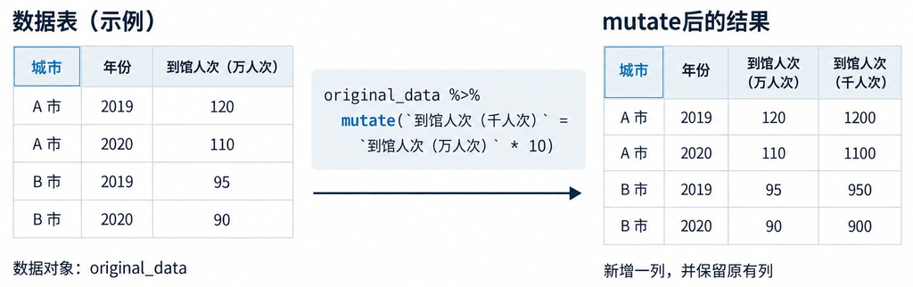

mutate() 根据已有变量计算新变量，同时保留原有记录

交互观察

###### 阈值如何改变分类结果？

根据分数生成分类标签，比较新增一列与更新已有列。

**查看示例数据**

示例数据：demo_data

| id | group | year | score | status |
| --- | --- | --- | --- | --- |
| 1 | A | 2020 | 55 | 未评定 |
| 2 | A | 2021 | 70 | 未评定 |
| 3 | B | 2020 | 70 | 未评定 |
| 4 | B | 2021 | 85 | 未评定 |
| 5 | C | 2020 | 85 | 未评定 |
| 6 | C | 2021 | 95 | 未评定 |

达标分数

结果写入

```
library(dplyr)

# 教学模拟数据：每行是一名学生的一次成绩记录
demo_data <- tibble::tibble(
  id = 1:6,
  group = c("A", "A", "B", "B", "C", "C"),
  year = c(2020, 2021, 2020, 2021, 2020, 2021),
  score = c(55, 70, 70, 85, 85, 95)
)
demo_data <- demo_data %>%
  mutate(status = "未评定")

demo_data %>%
  mutate(score_group = if_else(
    score >= 60, "达标", "待提升"
  ))
```

当前设置的运行结果

| id | group | year | score | status | score_group |
| --- | --- | --- | --- | --- | --- |
| 1 | A | 2020 | 55 | 未评定 | 待提升 |
| 2 | A | 2021 | 70 | 未评定 | 达标 |
| 3 | B | 2020 | 70 | 未评定 | 达标 |
| 4 | B | 2021 | 85 | 未评定 | 达标 |
| 5 | C | 2020 | 85 | 未评定 | 达标 |
| 6 | C | 2021 | 95 | 未评定 | 达标 |

分数达到 60 的记录标为“达标”。返回结果新增 score_group，已有 status 保持原值。当前代码没有赋值，demo_data 本身保持不变。 结果：6 行 × 6 列。

预览为本页所列设置的 R 计算结果；复制完整代码可在 R 中运行。

**选学：多类标签与批量计算**

`case_when()` 按顺序检查多条条件，采用第一条成立的结果。因此，重叠条件需要安排好先后顺序。

```r
practice_data %>%
  filter(year == 2007) %>%
  mutate(life_exp_band = case_when(
    life_exp < 60 ~ "低于60岁",
    life_exp < 75 ~ "60至不足75岁",
    life_exp >= 75 ~ "至少75岁",
    .default = "缺失"
  )) %>%
  select(country, life_exp, life_exp_band) %>%
  head(3)
```

```
# A tibble: 3 × 3
  country     life_exp life_exp_band
  <fct>          <dbl> <chr>
1 Afghanistan     43.8 低于60岁
2 Albania         76.4 至少75岁
3 Algeria         72.3 60至不足75岁
```

`across()` 可以把同一种计算应用到指定列。下面用一个函数，将两列数值分别保留一位小数：

```r
practice_data %>%
  mutate(across(c(life_exp, gdp_per_cap), function(x) round(x, 1))) %>%
  head(3)
```

```
# A tibble: 3 × 6
  country     continent  year life_exp      pop gdp_per_cap
  <fct>       <fct>     <int>    <dbl>    <int>       <dbl>
1 Afghanistan Asia       1952     28.8  8425333        779.
2 Afghanistan Asia       1957     30.3  9240934        821.
3 Afghanistan Asia       1962     32   10267083        853.
```

四舍五入适合整理展示结果，原始测量值通常另行保留。

**选学：为国家名称匹配标准代号**

`countrycode` 是额外的包，首次使用前在 Console 安装。通过 `countrycode::countrycode()` 指定函数来源，无需再加载该包。下面保存转换结果，再检查无法匹配的名称：

```r
country_codes <- practice_data %>%
  mutate(iso3 = countrycode::countrycode(
    country, origin = "country.name", destination = "iso3c"
  ))

country_codes %>%
  filter(is.na(iso3)) %>%
  select(country) %>%
  distinct()
```

```
# A tibble: 0 × 1
# ℹ 1 variable: country <fct>
```

未匹配时应核对名称、地区编码及历史口径，再决定是否建立人工对照表。名称相似不保证指向同一研究对象。

##### **汇总：`group_by()`**

###### **3.2.8 分组汇总**

`group_by()` 指定分组变量，使后续计算分别在组内进行；它本身不把多条记录合成一条。`summarise()` 才将每组汇总成一行。

下面比较 **2007 年**各洲所含国家的出生时预期寿命：

```r
continent_summary <- practice_data %>%
  filter(year == 2007) %>%
  group_by(continent) %>%
  summarise(
    n_country = n_distinct(country),
    life_exp_mean = mean(life_exp),
    .groups = "drop"
  )

continent_summary
```

```
# A tibble: 5 × 3
  continent n_country life_exp_mean
  <fct>         <int>         <dbl>
1 Africa           52          54.8
2 Americas         25          73.6
3 Asia             33          70.7
4 Europe           30          77.6
5 Oceania           2          80.7
```

每个国家在当年只有一条记录，所以均值为**国家之间的未加权均值**，不能直接解释为全洲人口的平均寿命。`.groups = "drop"` 取消结果中的分组状态，避免后续操作继续按旧分组执行。

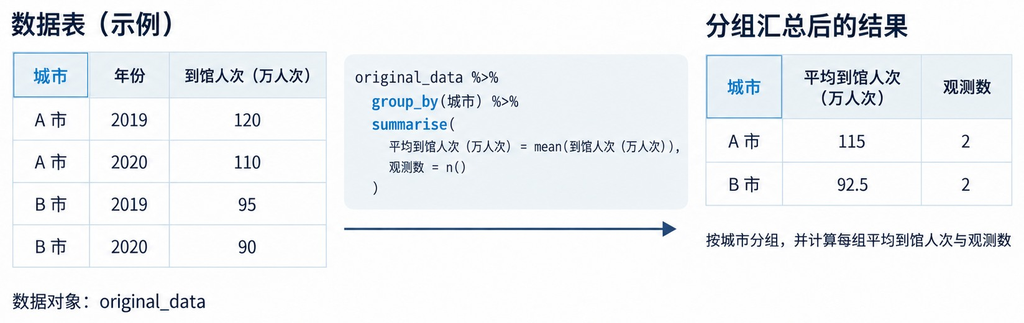

group_by() 指定城市分组，summarise() 为每组生成一行汇总结果

分组汇总中常见统计量的含义

| 统计目的 | 函数 | 需要辨认的含义 |
| --- | --- | --- |
| 数记录 | `n()` | 统计组内行数 |
| 数不同对象 | `n_distinct(country)` | 同一国家出现多次只计一次 |
| 算均值、中位数 | `mean()`、`median()` | 明确哪些记录参与计算 |
| 求总和 | `sum(pop)` | 总和仅覆盖数据集所含对象 |

交互观察

###### 分组条件决定每一行汇总的含义

选择分组变量与统计量，比较原始记录和汇总结果的行数。

**查看示例数据**

示例数据：demo_data

| id | group | year | score |
| --- | --- | --- | --- |
| 1 | A | 2020 | 55 |
| 2 | A | 2021 | 70 |
| 3 | B | 2020 | 70 |
| 4 | B | 2021 | 85 |
| 5 | C | 2020 | 85 |
| 6 | C | 2021 | 95 |

分组变量

统计量

```
library(dplyr)

# 教学模拟数据：每行是一名学生的一次成绩记录
demo_data <- tibble::tibble(
  id = 1:6,
  group = c("A", "A", "B", "B", "C", "C"),
  year = c(2020, 2021, 2020, 2021, 2020, 2021),
  score = c(55, 70, 70, 85, 85, 95)
)

demo_data %>%
  group_by(group) %>%
  summarise(mean_score = mean(score), .groups = "drop")
```

当前设置的运行结果

| group | mean_score |
| --- | --- |
| A | 62.5 |
| B | 77.5 |
| C | 90 |

每行对应一个小组。同组内的记录参与同一次计算。结果已取消分组。 结果：3 行 × 2 列。

预览为本页所列设置的 R 计算结果；复制完整代码可在 R 中运行。

**多个变量可以共同分组。** 按大洲与年份计算时，每行结果表示某洲在某年的国家均值：

```r
practice_data %>%
  group_by(continent, year) %>%
  summarise(
    life_exp_mean = mean(life_exp),
    .groups = "drop"
  ) %>%
  head(4)
```

```
# A tibble: 4 × 3
  continent  year life_exp_mean
  <fct>     <int>         <dbl>
1 Africa     1952          39.1
2 Africa     1957          41.3
3 Africa     1962          43.3
4 Africa     1967          45.3
```

只需要计数时，`count()` 更紧凑：

```r
practice_data %>%
  filter(year == 2007) %>%
  count(continent, name = "n_country")
```

```
# A tibble: 5 × 2
  continent n_country
  <fct>         <int>
1 Africa           52
2 Americas         25
3 Asia             33
4 Europe           30
5 Oceania           2
```

**先确认统计单位，再解读结果。** 对全部年份运行 `count(continent)` 数的是国家年度记录。若每行不是一个独立国家，就不能把行数称为国家数。遇到缺失值时，`na.rm = TRUE` 表示计算时排除缺失值；使用前应说明缺失数量及其影响。

**选学：汇总后连接回原记录，构建相对指标**

可先计算每年的国家均值，再连接回国家年度表。这里以 100 表示等于当年所含国家的未加权均值：

```r
year_benchmark <- practice_data %>%
  group_by(year) %>%
  summarise(
    country_mean = mean(life_exp),
    .groups = "drop"
  )

relative_data <- practice_data %>%
  left_join(year_benchmark, by = "year", relationship = "many-to-one") %>%
  mutate(life_exp_index = life_exp / country_mean * 100)

relative_data %>%
  filter(year == 2007) %>%
  select(country, life_exp, country_mean, life_exp_index) %>%
  head(3)
```

```
# A tibble: 3 × 4
  country     life_exp country_mean life_exp_index
  <fct>          <dbl>        <dbl>          <dbl>
1 Afghanistan     43.8         67.0           65.4
2 Albania         76.4         67.0          114.
3 Algeria         72.3         67.0          108.
```

该指标只是相对比较，不代表排名或人口加权结果。原表的国家与年份组合已经唯一，无需再次按这两列求均值。

##### **关联：`left_join()`**

###### **3.2.9 关联补充**

`left_join()` 依据匹配字段（key）连接两张表。左表记录至少保留一次；右表匹配成功的信息写入新列，未匹配处填为 `NA`。

下例用一张**教学模拟的展示分组表**为国家记录补充标签，分组没有现实分类含义：

```r
display_lookup <- tibble::tibble(
  country = c("China", "Japan", "Canada"),
  display_group = c("A组", "A组", "B组")
)

joined_data <- practice_data %>%
  left_join(display_lookup, by = "country", relationship = "many-to-one")

joined_data %>%
  filter(year == 2007, country %in% c("China", "Canada", "France")) %>%
  select(country, year, display_group)
```

```
# A tibble: 3 × 3
  country  year display_group
  <chr>   <int> <chr>
1 Canada   2007 B组
2 China    2007 A组
3 France   2007 <NA>
```

`by = "country"` 指定匹配列。`relationship = "many-to-one"` 声明每条左表记录最多匹配一条右表记录；右表若出现导致多重匹配的重复国家名称，R 会报错，便于发现问题。法国不在示例对照表中，因此其标签为 `NA`，这不代表属于某个相反类别。

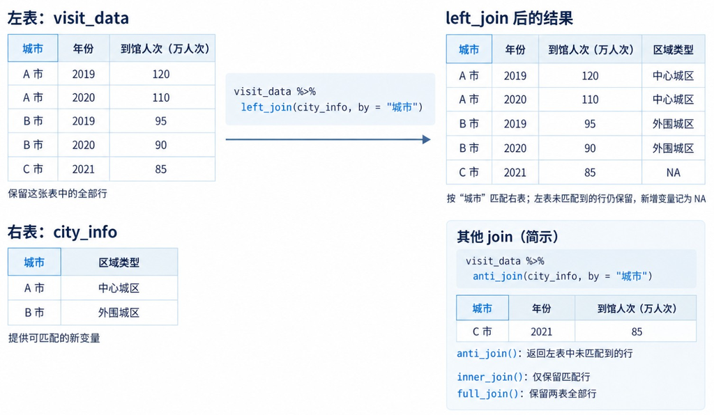

left_join() 保留左表记录并按城市补充区域类型，未匹配处为 NA

交互观察

###### 匹配字段与重复记录怎样影响连接？

两张表均记录城市年度信息。先用城市与年份共同匹配，再观察只按城市匹配的结果。

**查看示例数据**

示例数据：visits_data

| city | year | visits |
| --- | --- | --- |
| A | 2019 | 120 |
| A | 2020 | 110 |
| B | 2019 | 95 |
| B | 2020 | 90 |

示例数据：budget_data

| city | year | budget |
| --- | --- | --- |
| A | 2019 | 30 |
| A | 2020 | 32 |
| B | 2019 | 25 |
| B | 2020 | 28 |

匹配字段

右表记录

```
library(dplyr)
# 教学模拟数据；visits 为万人次，budget 为万元
visits_data <- tibble::tibble(
  city = c("A", "A", "B", "B"),
  year = c(2019, 2020, 2019, 2020),
  visits = c(120, 110, 95, 90)
)
budget_data <- tibble::tibble(
  city = c("A", "A", "B", "B"),
  year = c(2019, 2020, 2019, 2020),
  budget = c(30, 32, 25, 28)
)

visits_data %>%
  left_join(budget_data, by = c("city", "year"))
```

当前设置的运行结果

| city | year | visits | budget |
| --- | --- | --- | --- |
| A | 2019 | 120 | 30 |
| A | 2020 | 110 | 32 |
| B | 2019 | 95 | 25 |
| B | 2020 | 90 | 28 |

城市与年份共同确定年度记录。本例一对一匹配，4 条到馆记录分别取得对应预算。 结果：4 行 × 4 列。

预览为本页所列设置的 R 计算结果；复制完整代码可在 R 中运行。

**检查匹配关系，不能只看是否运行成功。** 右表某个 key 重复，可能使左表的一条记录匹配多行，形成一对多；两边对应 key 都重复时，可能形成多对多。连接后应检查行数、关键字段及未匹配记录。

字符与因子等部分类型可以兼容，字符与数值等不兼容类型通常会报错。转换类型前还要检查前导零、空格与字段含义，避免把不同编号误当成相同值。

```r
# 连接前后行数应符合预期
c(before = nrow(practice_data), after = nrow(joined_data))
```

```
before  after
  1704   1704
```

```r
# 检查对照表中不存在的国家
practice_data %>%
  filter(year == 2007) %>%
  anti_join(display_lookup, by = "country") %>%
  select(country) %>%
  head(3)
```

```
# A tibble: 3 × 1
  country
  <fct>
1 Afghanistan
2 Albania
3 Algeria
```

**选学：连接方式、不同列名与名称匹配**

根据记录保留范围选择连接方式

| 目的 | 函数 |
| --- | --- |
| 保留两边都匹配的记录 | `inner_join()` |
| 保留两表全部记录 | `full_join()` |
| 按右表保留记录 | `right_join()` |
| 找出左表未匹配记录 | `anti_join()` |
| 仅筛出左表能匹配的记录，不添加右表列 | `semi_join()` |

匹配字段名称不同时，可写 `by = c("country" = "country_name")`，左侧是左表列名，右侧是右表列名。城市年度数据通常还需加入年份，避免跨年错配。实际记录的 key 缺失时也应先检查；本地等值连接默认允许 `NA` 与 `NA` 匹配。

名称不一致时，先核对拼写、空格、简称和正式编码。模糊匹配（fuzzy matching）可以提供相似候选，但简称与全称不一定具有较高的字符相似度，匹配后仍需人工核验。入门阶段先掌握明确 key 的连接，延伸方法见 [R for Data Science：Joins](https://r4ds.hadley.nz/joins.html)。

##### **追加：`bind_rows()`**

###### **3.2.10 按行追加**

不同年份或调查批次的数据，如果每行记录的含义一致，可以使用 `bind_rows()` 叠放到同一张表中。它**按列名对齐**，不会依据 key 查找对应记录，也不会自动去重。

```r
data_2002 <- practice_data %>% filter(year == 2002)
data_2007 <- practice_data %>% filter(year == 2007)

combined_data <- bind_rows(
  "2002_batch" = data_2002,
  "2007_batch" = data_2007,
  .id = "source_batch"
)

combined_data %>% count(source_batch)
```

```
# A tibble: 2 × 2
  source_batch     n
  <chr>        <int>
1 2002_batch     142
2 2007_batch     142
```

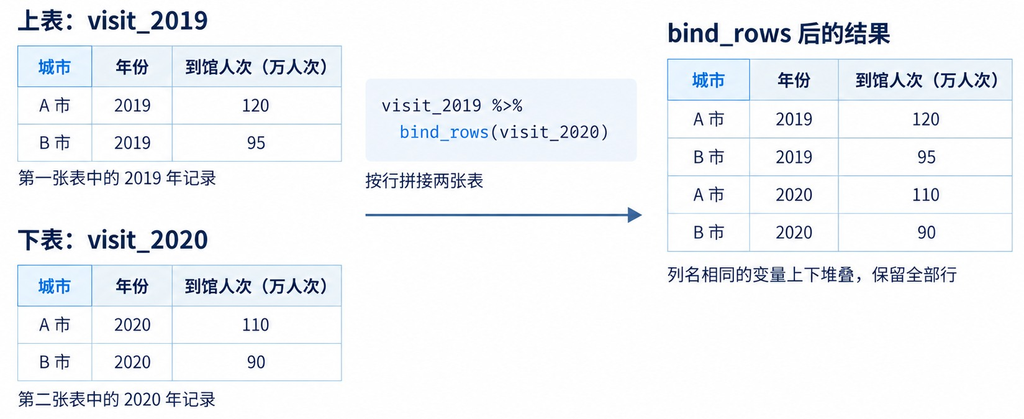

bind_rows() 将列结构一致的 2019 年与 2020 年记录按行追加

`.id = "source_batch"` 新增一列记录来源。某一批数据缺少的列会补为 `NA`；同名列的类型需要兼容。追加前应核对变量含义、计量单位和编码规则，列名相同并不保证口径一致。

**选学：按行追加、按 key 连接与按位置拼列**

`bind_rows()` 增加记录，`left_join()` 按 key 补充信息。`bind_cols()` 则直接按当前行位置拼列，不检查同一行是否属于同一个对象。只有两边行数、顺序与记录含义均已确认对应时，才适合按位置拼列。

##### **拆合：`separate_wider_delim()`**

###### **3.2.11 字段拆合**

当同一列按固定规则合存多个变量时，`separate_wider_delim()` 可以按分隔符拆列。下例的 `profile` 依次保存姓名代号、性别代码和年龄，其中 `M`、`F` 分别表示男性、女性。

```r
messy_people <- tibble::tibble(
  id = 1:4,
  profile = c("Li_M_23", "Wang_F_19", "Zhang_M_31", "Chen_F_26")
)

clean_people <- messy_people %>%
  separate_wider_delim(
    cols = profile, delim = "_",
    names = c("name", "sex", "age")
  ) %>%
  mutate(age = readr::parse_integer(age))

clean_people
```

```
# A tibble: 4 × 4
     id name  sex     age
  <int> <chr> <chr> <int>
1     1 Li    M        23
2     2 Wang  F        19
3     3 Zhang M        31
4     4 Chen  F        26
```

`cols` 指定待拆列，`delim` 指定固定分隔符，`names` 依次命名结果列。拆分后的年龄起初是字符，`parse_integer()` 将其解析为整数。某条记录的片段数与预期不符时，默认会报错，应先检查原始记录。

反过来，`unite()` 按指定分隔符把多列连接成字符：

```r
clean_people %>%
  unite(profile_text, name, sex, age, sep = "_", remove = FALSE)
```

```
# A tibble: 4 × 5
     id profile_text name  sex     age
  <int> <chr>        <chr> <chr> <int>
1     1 Li_M_23      Li    M        23
2     2 Wang_F_19    Wang  F        19
3     3 Zhang_M_31   Zhang M        31
4     4 Chen_F_26    Chen  F        26
```

`remove = FALSE` 保留参与拼接的原列；默认 `TRUE` 会在返回结果中移除这些列。这里的 `profile_text` 用于展示，分析时仍可直接使用独立的姓名、性别和年龄列。

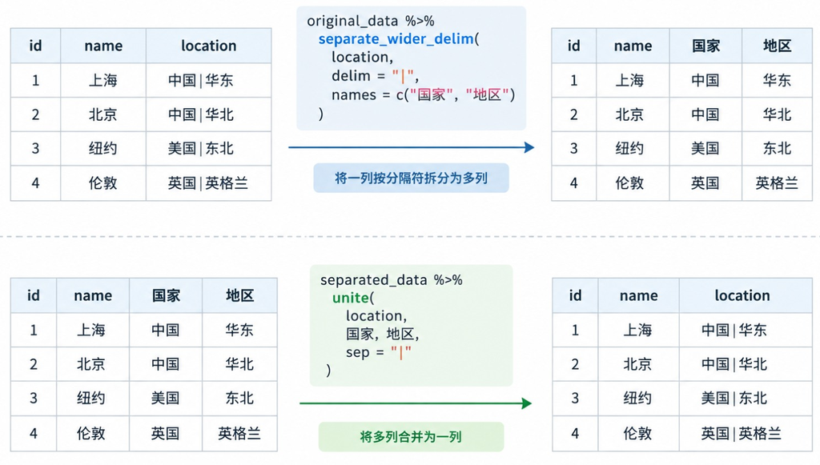

separate_wider_delim() 按分隔符拆列，unite() 按指定分隔符合并多列

**选学：旧函数与日期时间的处理边界**

旧函数 `separate()` 仍可运行，但官方已标记为 superseded。按固定分隔符拆分的新代码优先使用 `separate_wider_delim()`；两者参数名称和分隔规则有区别，不能只替换函数名。

拼接日期各部分得到的仍是字符。若需要时间计算，可直接构造日期时间对象：

```r
time_parts <- tibble::tibble(
  year = c(2025, 2025), month = c(4, 4), day = c(29, 30),
  hour = c(19, 8), minute = c(3, 45), second = c(52, 10)
)

time_parts %>%
  mutate(timestamp = lubridate::make_datetime(
    year, month, day, hour, minute, second, tz = "Asia/Shanghai"
  ))
```

```
# A tibble: 2 × 7
   year month   day  hour minute second timestamp
  <dbl> <dbl> <dbl> <dbl>  <dbl>  <dbl> <dttm>
1  2025     4    29    19      3     52 2025-04-29 19:03:52
2  2025     4    30     8     45     10 2025-04-30 08:45:10
```

##### **转换：`pivot_*()`**

###### **3.2.12 长宽转换**

`pivot_longer()` 把多列测量值整理为名称列和值列；`pivot_wider()` 将名称列的取值展开为列名。选择排法时，需要明确一行代表什么，以及后续计算所需的结构。

下面用两座城市的年度到馆人次演示，单位为万人次，均为模拟数据：

```r
wide_data <- tibble::tibble(
  city = c("A", "B"),
  `2019` = c(120, 95),
  `2020` = c(110, 90)
)

wide_data
```

```
# A tibble: 2 × 3
  city  `2019` `2020`
  <chr>  <dbl>  <dbl>
1 A        120    110
2 B         95     90
```

**宽表转长表：让年份进入一列。**

```r
long_data <- wide_data %>%
  pivot_longer(
    cols = c(`2019`, `2020`),
    names_to = "year",
    values_to = "visits",
    names_transform = list(year = as.integer)
  )

long_data
```

```
# A tibble: 4 × 3
  city   year visits
  <chr> <int>  <dbl>
1 A      2019    120
2 A      2020    110
3 B      2019     95
4 B      2020     90
```

`cols` 指定需要收集的年份列，`names_to` 接收原列名，`values_to` 接收原单元格数值。`names_transform` 把年份转换为整数。结果为四行，每行表示一条城市年度记录，四个到馆人次数值都保留。

**长表转宽表：把年份取值展开为列名。**

```r
wide_again <- long_data %>%
  pivot_wider(
    id_cols = city,
    names_from = year,
    values_from = visits
  )

wide_again
```

```
# A tibble: 2 × 3
  city  `2019` `2020`
  <chr>  <dbl>  <dbl>
1 A        120    110
2 B         95     90
```

`id_cols = city` 表示宽表中每个城市占一行。`names_from` 指定新列名取自年份，`values_from` 指定单元格填入到馆人次。

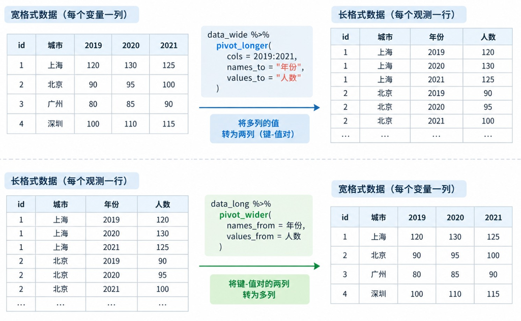

pivot_longer() 将年份列整理为名称和值两列，pivot_wider() 执行相反方向的转换

交互观察

###### 列名与数值在长宽转换中去向何处？

使用同一组城市到馆人次，比较长表与宽表。数值单位为万人次，均为教学模拟数据。

**查看示例数据**

示例数据：wide_data

| city | 2019 | 2020 |
| --- | --- | --- |
| A | 120 | 110 |
| B | 95 | 90 |

转换方向

长表中的列名

宽表列名前缀默认不添加前缀。

```
library(tidyverse)
wide_data <- tibble::tibble(
  city = c("A", "B"),
  `2019` = c(120, 95),
  `2020` = c(110, 90)
)

wide_data %>%
  pivot_longer(
    cols = c(`2019`, `2020`),
    names_to = "year", values_to = "visits",
    names_transform = list(year = as.integer)
  )
```

当前设置的运行结果

| city | year | visits |
| --- | --- | --- |
| A | 2019 | 120 |
| A | 2020 | 110 |
| B | 2019 | 95 |
| B | 2020 | 90 |

原列名中的年份进入 year；四个到馆人次数值进入 visits。结果为 4 行，每行一条城市年度记录。 结果：4 行 × 3 列。

预览为本页所列设置的 R 计算结果；复制完整代码可在 R 中运行。

同一个结果位置应对应一个值。 若同一城市同一年存在多条到馆记录，`pivot_wider()` 无法直接决定填哪一个值，可能提示并生成列表列。应先核对观测单位和重复原因；只有确实需要汇总时，才通过 `values_fn` 指定计算，不能用求均值掩盖重复问题。

长表与宽表都可能适合分析。不同独立变量各占一列的宽表可以符合整洁规则；年份作为变量时，将年份取值单独列出通常更便于按年筛选和分组。转换应服务于变量含义和分析任务。

##### **3.3 自测与资源**

01运行 practice_data %>% filter(year == 2007) 后，原对象会怎样？ 原对象只剩下 2007 年记录 原对象不变，表达式返回筛选结果 原对象自动按年份分组

02在相同数据顺序与运行环境下，哪种操作可以复现第一次抽样？ 只设置一次种子，随后不断抽样 每次换一个更大的种子 重设相同种子，再运行相同抽样代码

03按大洲分组后计算 mean(life_exp)，每行汇总结果表示什么？ 一个大洲中参与计算记录的寿命均值 一个国家的原始寿命记录 自动按人口加权得到的大洲寿命

**函数文档与延伸阅读**

- [dplyr 数据转换入门](https://dplyr.tidyverse.org/articles/dplyr.html)：按数据任务查找行列操作与分组写法。
- [slice 系列函数](https://dplyr.tidyverse.org/reference/slice.html)：核对数量、比例、放回抽样及并列值参数。
- [R 随机数与种子说明](https://stat.ethz.ch/R-manual/R-devel/library/base/html/Random.html)：了解种子和随机数状态的关系。
- [tidyr 长宽转换](https://tidyr.tidyverse.org/articles/pivot.html)：查阅更复杂的列名和多变量转换示例。

## **4.0 数据清洗与诊断**

### **4.0 数据清洗与诊断**

#### **清洗主题**

##### **清洗导航**

**从质量诊断到可核对的清洗结果**

数据清洗（data cleaning）用于识别并处理会妨碍计算或扭曲解释的数据问题。整洁数据规定变量、观测与取值如何排列表格；质量诊断进一步检查记录是否缺失、重复、误编码或命名不一致。

1. 01**明确规则**写清观测单位、key、变量含义与允许取值。
2. 02**量化问题**统计缺失、重复、类型与异常编码。
3. 03**选择处理**依据采集过程和分析目标决定删除、修正或保留。
4. 04**复核变化**比较处理前后的行数、缺失数、类型与 key 唯一性。

清洗时应保留原始文件，将处理结果写入新对象，并记录每一步的判断依据。这样才能发现误删、误填或单位转换错误。

**从空会话运行本节代码**

先加载 `tidyverse`。其余示例会在使用对象前创建对象；`janitor` 仅在 4.4 通过 `janitor::clean_names()` 调用。

```r
library(tidyverse)
```

##### 缺失值：`NA`

###### **4.1 识别与处理缺失值**

R 使用 `NA` 表示缺失值（missing value）。`NA` 说明某个取值未知或未记录，但没有说明缺失原因。它也不同于数值 `0`、空字符串 `""` 和文本 `"NA"`；后两者仍是普通字符，读取数据时未必会自动转换为真正的缺失值。

常见空值形式及其含义

| 数据中的形式 | R 的理解 | 处理前需要确认的事项 |
| --- | --- | --- |
| `NA` | 缺失值 | 缺失如何产生，是否影响当前分析变量 |
| `0` | 数值零 | 零是否表示真实的“没有”或“未发生” |
| `""` | 长度为零的文本 | 空白是否应重编码为 `NA` |
| `"NA"`、`"未知"` | 普通文本标签 | 数据字典是否把这些标签定义为缺失 |

###### **4.1.1 定位与统计**

`is.na()` 对每个元素进行判断，`anyNA()` 只回答对象中是否存在缺失值。需要统计数量时，可对 `is.na()` 的逻辑结果求和。判断缺失值应写作 `is.na(visits)`；表达式 `visits == NA` 的比较结果仍是 `NA`，无法筛出缺失记录。

缺失值诊断中常用的四种写法

| 任务 | 写法 | 返回内容 |
| --- | --- | --- |
| 判断对象是否含缺失值 | `anyNA(data)` | 一个 `TRUE` 或 `FALSE` |
| 逐项标记缺失位置 | `is.na(data)` | 与原对象对应的逻辑结果 |
| 统计某列缺失数量 | `sum(is.na(data$visits))` | 一个计数值 |
| 查看某列缺失的记录 | `filter(data, is.na(visits))` | 满足条件的行 |

```r
# 教学模拟数据：每行是一座城市在一个年份的记录
missing_data <- tibble::tibble(
  city = c("A 市", "A 市", "B 市", "B 市"),
  year = c(2019, 2020, 2019, 2020),
  visits = c(120, NA, 100, 80),
  status = c("开放", "开放", NA, "开放")
)

# 数据中是否存在缺失值
anyNA(missing_data)
```

```
  [1] TRUE
```

```r
# 分别统计两个变量中的缺失数量
missing_data %>%
  summarise(
    n_missing_visits = sum(is.na(visits)),
    n_missing_status = sum(is.na(status))
  )
```

```
  # A tibble: 1 × 2
    n_missing_visits n_missing_status
               <int>            <int>
  1                1                1
```

```r
# 查看 visits 缺失的记录
missing_data %>%
  filter(is.na(visits))
```

```
  # A tibble: 1 × 4
    city   year visits status
    <chr> <dbl>  <dbl> <chr>
  1 A 市   2020     NA 开放
```

**`na.rm = TRUE` 只改变当前计算**

许多统计函数遇到 `NA` 时会返回 `NA`。参数 `na.rm = TRUE` 表示在**当前统计量**中排除缺失观测；它不会填补或删除原数据中的缺失值。排除后，有效样本量和分母可能改变，因此结果应同时说明参与计算的记录数。

```r
mean(c(1, 2, NA, 4))
```

```
  [1] NA
```

```r
mean(c(1, 2, NA, 4), na.rm = TRUE)
```

```
  [1] 2.333333
```

###### **4.1.2 选择处理方式**

处理缺失值前，需要结合数据来源、变量用途和缺失机制决定方案。删除会改变分析样本；填补会加入原本没有观测到的数值；保留缺失则要求后续函数能够明确处理 `NA`。

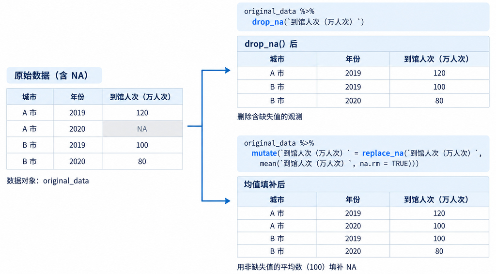

缺失记录删除与均值填补会改变样本行数或数值分布

图中的 `original_data` 代表尚未清洗的原表。均值填补用于比较两种操作产生的差异，不代表正式分析中的默认选择。

三类缺失值处理方式的用途与边界

| 处理方式 | 常用操作 | 适用条件与影响 |
| --- | --- | --- |
| 删除记录 | `drop_na()` | 删除含指定缺失值的行；需检查样本构成与样本量变化 |
| 填入明确类别或数值 | `replace_na()` | 只有数据字典或研究设计能够支持该替代值时才使用 |
| 沿相邻记录补齐 | `fill()` | 适合组内本应重复记录的属性；必须先分组、排序并核对时间连续性 |

```r
# 仅删除 visits 缺失的城市年度记录
missing_data %>%
  drop_na(visits)
```

```
  # A tibble: 3 × 4
    city   year visits status
    <chr> <dbl>  <dbl> <chr>
  1 A 市   2019    120 开放
  2 B 市   2019    100 <NA>
  3 B 市   2020     80 开放
```

```r
# 教学比较：用非缺失值的均值生成一个新变量
missing_data %>%
  mutate(
    visits_mean_demo = replace_na(
      visits,
      mean(visits, na.rm = TRUE)
    ),
    status = replace_na(status, "未记录")
  )
```

```
  # A tibble: 4 × 5
    city   year visits status visits_mean_demo
    <chr> <dbl>  <dbl> <chr>             <dbl>
  1 A 市   2019    120 开放                120
  2 A 市   2020     NA 开放                100
  3 B 市   2019    100 未记录              100
  4 B 市   2020     80 开放                 80
```

固定值填补只有在缺失含义明确时才成立。“未填写”不能直接解释为“无”或 `0`。均值、中位数和单次模型填补都会改变变量分布，并低估填补带来的不确定性。

**选学：缺失机制与进阶处理的边界**

- 缺失完全随机（missing completely at random, MCAR）要求缺失概率与已观测和未观测信息都无关，这一条件通常需要结合采集过程判断。
- 模型填补利用其他变量预测缺失值。单次预测会把一个估计值当作已知值，不能反映填补不确定性。
- 多重插补（multiple imputation）生成多份合理的完整数据并合并估计，更适合正式推断，但需要单独学习模型设定与诊断。
- 时间序列插值依赖局部连续性。观测间隔不规则、缺失区间较长或发生结构变化时，平滑结果可能掩盖真实变化。

##### 重复记录：`distinct()`

###### **4.2 识别重复记录**

重复记录（duplicate records）可能来自重复导入、一对多连接，也可能是同一对象的多次有效测量。判定重复之前必须明确观测单位和 key。若每行表示“一座城市在一个年份的记录”，则 `city + year` 才能共同标识一条城市年度观测；同一城市出现在多个年份是合理现象。

**三种需要分开的情况**

- **整行重复**：所有变量完全相同，常见于重复导入。
- **key 重复**：应当唯一的 key 出现多次，但其他值可能不同，需要追查来源或制定保留规则。
- **有效重复测量**：同一对象在不同时间或条件下被多次记录，应保留区分这些观测的变量。

###### **4.2.1 重复组与额外行**

“重复记录数”至少有两种口径。`nrow(data) - nrow(distinct(data))` 计算每组保留一行后多出的**额外行数**；`filter(n() > 1)` 返回属于重复组的**全部记录**。报告结果时应写明采用哪一种口径。

```r
# 教学模拟数据：每行是一座城市在一个年份的到馆记录
duplicate_data <- tibble::tibble(
  city = c("A 市", "A 市", "A 市", "B 市", "B 市", "B 市"),
  year = c(2019, 2020, 2020, 2019, 2020, 2020),
  visits = c(120, 110, 110, 95, 90, 90)
)

# 定位整行重复组，并显示每组包含的记录数
duplicate_data %>%
  count(city, year, visits, name = "n") %>%
  filter(n > 1)
```

```
  # A tibble: 2 × 4
    city   year visits     n
    <chr> <dbl>  <dbl> <int>
  1 A 市   2020    110     2
  2 B 市   2020     90     2
```

```r
# 计算每组只保留一行后，多出的额外行数
n_extra_rows <- nrow(duplicate_data) - nrow(distinct(duplicate_data))
n_extra_rows
```

```
  [1] 2
```

```r
# 检查 city + year 这个 key 是否重复
duplicate_data %>%
  count(city, year, name = "n") %>%
  filter(n > 1)
```

```
  # A tibble: 2 × 3
    city   year     n
    <chr> <dbl> <int>
  1 A 市   2020     2
  2 B 市   2020     2
```

###### **4.2.2 按 key 去重**

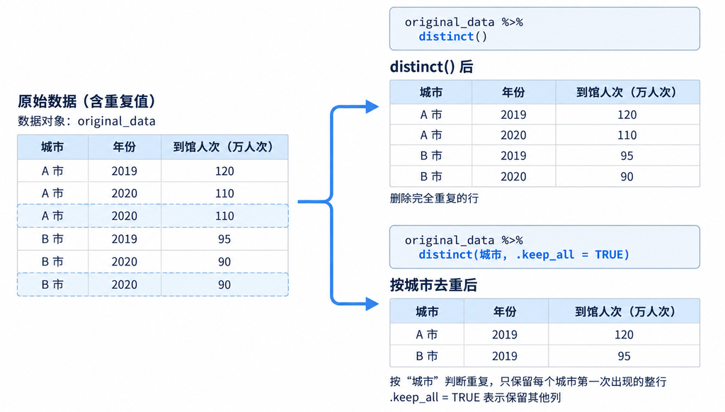

整行去重与仅按城市去重产生的不同结果

图中上方的 `distinct()` 删除两条额外的整行副本，仍保留 4 条城市年度记录。下方仅按 `city` 去重后只剩 2 行，因为 key 与观测单位不一致；该分支用于说明错误选择 key 的后果。

交互观察

###### key 改变时，哪些城市年度记录会被保留？

同一张表分别按全部变量、城市与年份、仅城市判断重复。观察 key 与观测单位不一致时发生的数据丢失。

**查看示例数据**

示例数据：original_data

| city | year | visits |
| --- | --- | --- |
| A 市 | 2019 | 120 |
| A 市 | 2020 | 110 |
| A 市 | 2020 | 110 |
| B 市 | 2019 | 95 |
| B 市 | 2020 | 90 |
| B 市 | 2020 | 90 |

重复判断依据key 应与一行所代表的观测单位一致。

```
library(dplyr)
# 教学模拟数据：每行是一座城市在一个年份的到馆记录
original_data <- tibble::tibble(
  city = c("A 市", "A 市", "A 市", "B 市", "B 市", "B 市"),
  year = c(2019, 2020, 2020, 2019, 2020, 2020),
  visits = c(120, 110, 110, 95, 90, 90)
)

original_data %>%
  distinct()
```

当前设置的运行结果

| city | year | visits |
| --- | --- | --- |
| A 市 | 2019 | 120 |
| A 市 | 2020 | 110 |
| B 市 | 2019 | 95 |
| B 市 | 2020 | 90 |

所有变量完全相同的副本被删除。A 市和 B 市的 2019、2020 年记录仍被保留。 结果：4 行 × 3 列。

预览为本页所列设置的 R 计算结果；复制完整代码可在 R 中运行。

**`.keep_all = TRUE` 不会决定哪条记录更可信**

`distinct(city, year, .keep_all = TRUE)` 对每个 key 保留当前排序中的第一行。若重复行的数值不同，应先追查差异来源，并按照日期、版本或质量标记写出可复核的保留规则。单纯改变排序只能改变保留结果，不能证明该记录正确。

##### 格式与类型：`stringr`、`readr`

###### **4.3 清理格式与编码**

多源数据常把同一类别写成不同形式，例如 `"上海"` 与 `" 上海 "`；也可能把 `"N/A"`、`"未知"` 或空字符串保存在字符列中。货币符号、百分号和单位还会使本应参与计算的数值被读取为字符。清洗目标是让同一种含义采用同一种编码，并保留单位与转换规则。

字符与数值格式问题的常用处理

| 问题 | 常用函数 | 处理结果 |
| --- | --- | --- |
| 首尾含空白 | `str_trim()` | 删除字符串两端的空白 |
| 内部连续空白 | `str_squish()` | 首尾去空白，并把内部连续空白压为一个空格 |
| 大小写混用 | `str_to_lower()`、`str_to_upper()` | 按数据字典统一大小写 |
| 文本型缺失编码 | `na_if()` | 将指定文本转换为真正的 `NA` |
| 数字附带符号或单位 | `parse_number()` | 提取第一个可解析的数字，尺度仍需另行处理 |

```r
# 教学模拟数据：文本、缺失编码和数字格式并存
format_data <- tibble::tibble(
  city = c(" 上海", "北京 ", "广州"),
  district = c("浦东  新区", "N/A", ""),
  income = c("¥2,500", "3,000 元", "4,200 元"),
  participation_rate = c("35%", "42%", "N/A")
)

clean_format_data <- format_data %>%
  mutate(
    city = str_trim(city),
    district = str_squish(district),
    district = na_if(district, "N/A"),
    district = na_if(district, ""),
    participation_rate = na_if(participation_rate, "N/A"),
    income_yuan = parse_number(income),
    participation_rate = parse_number(participation_rate) / 100
  )

clean_format_data
```

```
  # A tibble: 3 × 5
    city  district  income   participation_rate income_yuan
    <chr> <chr>     <chr>                 <dbl>       <dbl>
  1 上海  浦东 新区 ¥2,500                 0.35        2500
  2 北京  <NA>      3,000 元               0.42        3000
  3 广州  <NA>      4,200 元              NA           4200
```

**`parse_number()` 提取数字，不判断尺度**

`parse_number("35%")` 返回 `35`。若分析变量按 0 到 1 的比例保存，还需除以 `100`。同理，`parse_number("12 公里")` 返回 `12`，但不会保留“公里”这个单位，也不会把“12 万元”自动换算为 `120000`。单位和换算规则应写入变量说明并在清洗后核对。

##### 列名规范：`janitor`

###### **4.4 统一列名为 `snake_case`**

含空格、括号和符号的列名需要用反引号引用，也容易在连续处理时写错。本课程采用 `snake_case`：英文小写单词之间使用下划线，例如 `annual_income`。这是课程和项目的统一约定，并非所有 R 项目的唯一规范。

`janitor::clean_names()` 可以批量规范列名。首次使用前，可在 Console 中运行 `install.packages("janitor")`；安装完成后，Rmd 通过 `包名::函数名()` 直接调用函数。

`clean_names()` 对示例列名的实际转换结果

| 原列名 | 清洗后列名 |
| --- | --- |
| `First Name` | `first_name` |
| `Annual Income ($)` | `annual_income` |
| `% Change` | `percent_change` |

```r
bad_names_data <- tibble::tibble(
  `First Name` = "John",
  `Annual Income ($)` = 50000,
  `% Change` = 0.05
)

clean_names_data <- bad_names_data %>%
  janitor::clean_names()

names(clean_names_data)
```

```
  [1] "first_name"     "annual_income"  "percent_change"
```

清洗后应立即运行 `names()` 核对结果。后续代码必须使用新的列名；列名规范化不会改变单元格中的数据。

**完成清洗后的最低检查**

- 比较处理前后的行数和列数，确认变化与预期一致。
- 重新统计关键变量的缺失值，并检查变量类型、单位与允许范围。
- 使用分析所需的 key 检查唯一性；重复测量数据还应确认时间或条件变量仍被保留。
- 抽查若干原始记录与清洗结果，并保存清洗代码和判断依据。

##### **4.5 自测与资源**

01运行 mean(c(10, 20, NA, 30), na.rm = TRUE) 后，哪项解释正确？ 原向量中的 `NA` 已被永久删除 当前均值排除缺失值，原向量没有改变 `NA` 被自动填为 0

02每行表示“一座城市在一个年份的记录”时，检查重复最合适的 key 是什么？ 仅使用 `city` 仅使用 `year` 同时使用 `city` 与 `year`

03若比例变量应保存为 0 到 1，parse_number("35%") 后还需进行哪一步？ 将结果除以 100 将结果乘以 100 不需要处理，函数会自动返回 0.35

**函数文档与延伸阅读**

- [tidyr 缺失值删除与替换](https://tidyr.tidyverse.org/reference/drop_na.html)：核对 `drop_na()` 的列选择规则；相关页面可继续进入 `replace_na()` 与 `fill()` 文档。
- [dplyr 重复记录处理](https://dplyr.tidyverse.org/reference/distinct.html)：查阅 `distinct()` 的变量选择与 `.keep_all` 参数。
- [stringr 空白处理](https://stringr.tidyverse.org/reference/str_trim.html)：比较 `str_trim()` 与 `str_squish()`。
- [readr 数字解析](https://readr.tidyverse.org/reference/parse_number.html)：查阅地区格式、分组符号与小数点设置。
- [janitor 列名清洗](https://sfirke.github.io/janitor/reference/clean_names.html)：核对 `clean_names()` 的命名规则与可选参数。

## **5.0 探索性数据分析**

### **5.0 探索性数据分析**

重要

**探索性数据分析** （Exploratory Data Analysis，EDA） 是一组用来认识数据、发现问题并形成后续分析判断的检查活动。统计学家 **John W. Tukey** 在 1977 年出版的 *Exploratory Data Analysis* 中系统阐述了这一思路：先观察数据呈现出的分布、差异和异常，再决定哪些统计方法与研究问题相匹配。

EDA 会出现在变量构造、建模和结果复核等多个阶段。一次检查可能暴露新的缺失、编码问题或组别差异；完成修正后，还需重新查看相关摘要。因此，EDA 通常是一个反复检查并记录判断的过程。

#### **5.0.1 EDA 关注的问题**

一份可复核的探索记录，至少应回答四类问题。

**一行代表什么？**

明确观测单位、时间范围和分析样本。例如，一行可能是一名受访者，也可能是一个国家在某一年的记录。

**数据能否直接使用？**

检查变量类型、缺失、重复、异常编码与合理范围。极端值需要核对来源，不能仅凭数值大小删除。

**单个变量怎样分布？**

查看中心位置、离散程度、偏态和极端记录。均值与标准差并非所有连续变量的固定搭配。

**组别和变量之间有何关系？**

比较各组构成与统计量，再检查变量关系的方向、形态和样本量。描述性差异本身不提供因果解释。

#### **5.0.2 EDA 检查顺序**

EDA 没有适用于所有研究的固定清单。下面的顺序适合社会科学数据的初次检查，也便于在分析日志中记录每一步的发现和处理决定。

1. **确认分析单位**写明一行记录谁或什么、时间点和纳入范围。
2. **检查结构与完整性**核对变量名、类型、总行数、有效值数和缺失数。
3. **描述单变量**根据分布选择均值与标准差，或中位数与四分位距。
4. **比较关键组别**检查组别样本量、构成比例和组内统计量。
5. **检查变量关系**结合关系形态、相关系数、完整观测数和研究背景解读。
6. **记录异常与决定**保存发现、处理依据及修正后的复查结果。

**探索与验证的边界**

查看数据后产生的新解释或假设，应在报告中标明为探索性发现。需要验证的研究问题通常还要结合预先设定的假设、独立数据或合适的研究设计。EDA 可以发现关联和数据问题，不能单独建立因果关系。

#### **5.1 EDA 工具**

##### **工具导航**

**探索性数据分析工具**

4 个入口依次完成数据概览、描述统计、分组比较和关系检查。

###### **运行准备**

本节继续使用 Gapminder。为使代码能够从空会话按顺序运行，先加载包并建立统一使用的分析对象。

```r
library(tidyverse)
library(gapminder)

eda_data <- gapminder %>%
  transmute(
    country,
    continent,
    year,
    life_expectancy = lifeExp,
    population = pop,
    gdp_per_capita = gdpPercap
  )

eda_2007 <- eda_data %>%
  filter(year == 2007)

glimpse(eda_2007)
```

```
  Rows: 142
  Columns: 6
  $ country         <fct> "Afghanistan", "Albania", "Algeria", "Angola", "Argent…
  $ continent       <fct> Asia, Europe, Africa, Africa, Americas, Oceania, Europ…
  $ year            <int> 2007, 2007, 2007, 2007, 2007, 2007, 2007, 2007, 2007, …
  $ life_expectancy <dbl> 43.828, 76.423, 72.301, 42.731, 75.320, 81.235, 79.829…
  $ population      <int> 31889923, 3600523, 33333216, 12420476, 40301927, 20434…
  $ gdp_per_capita  <dbl> 974.5803, 5937.0295, 6223.3675, 4797.2313, 12779.3796,…
```

准备块只调整本节使用的列名，没有改动 `gapminder` 原对象。后续输出中的一行表示“一个国家在一个年份的记录”；`eda_2007` 则固定为 2007 年截面。

##### 数据概览

###### **5.1.1 检查结构、范围与缺失**

初次接触一份数据时，应先确认变量类型、取值范围和缺失情况。`summary()` 适合快速查看基础摘要；`skimr::skim()` 会把不同类型变量的统计量整理成结构化报告。

**基础扫描：`summary()`**

对数值变量，`summary()` 通常给出最小值、四分位数、中位数、均值和最大值；对分类变量，它会显示各类别的记录数。输出内容会随变量类型变化。

```r
summary(eda_data)
```

```
          country        continent        year      life_expectancy
   Afghanistan:  12   Africa  :624   Min.   :1952   Min.   :23.60
   Albania    :  12   Americas:300   1st Qu.:1966   1st Qu.:48.20
   Algeria    :  12   Asia    :396   Median :1980   Median :60.71
   Angola     :  12   Europe  :360   Mean   :1980   Mean   :59.47
   Argentina  :  12   Oceania : 24   3rd Qu.:1993   3rd Qu.:70.85
   Australia  :  12                  Max.   :2007   Max.   :82.60
   (Other)    :1632
     population        gdp_per_capita
   Min.   :6.001e+04   Min.   :   241.2
   1st Qu.:2.794e+06   1st Qu.:  1202.1
   Median :7.024e+06   Median :  3531.8
   Mean   :2.960e+07   Mean   :  7215.3
   3rd Qu.:1.959e+07   3rd Qu.:  9325.5
   Max.   :1.319e+09   Max.   :113523.1
```

人口等较大数值可能以科学计数法显示。这只是打印格式，不会改变对象中的数值。

**结构化扫描：`skimr::skim()`**

`skimr` 不属于 `tidyverse` 核心包。首次使用前，可在 Console 中运行 `install.packages("skimr")`。课程代码使用 `skimr::` 明确函数来源，无需另行运行 `library(skimr)`。

```r
eda_data %>%
  skimr::skim() %>%
  skimr::focus(
    skim_variable,
    n_missing,
    complete_rate,
    numeric.mean,
    numeric.sd,
    numeric.hist
  )
```

Data summary

| Name | Piped data |
| --- | --- |
| Number of rows | 1704 |
| Number of columns | 6 |
| _______________________ |  |
| Column type frequency: |  |
| factor | 2 |
| numeric | 4 |
| ________________________ |  |
| Group variables | None |

**Variable type: factor**

| skim_variable | n_missing | complete_rate |
| --- | --- | --- |
| country | 0 | 1 |
| continent | 0 | 1 |

**Variable type: numeric**

| skim_variable | n_missing | complete_rate | mean | sd | hist |
| --- | --- | --- | --- | --- | --- |
| year | 0 | 1 | 1979.50 | 17.27 | ▇▅▅▅▇ |
| life_expectancy | 0 | 1 | 59.47 | 12.92 | ▁▆▇▇▇ |
| population | 0 | 1 | 29601212.32 | 106157896.74 | ▇▁▁▁▁ |
| gdp_per_capita | 0 | 1 | 7215.33 | 9857.45 | ▇▁▁▁▁ |

阅读输出时，可先查看三类信息：`n_missing` 和 `complete_rate` 描述完整性；`numeric.mean` 与 `numeric.sd` 给出数值摘要；`numeric.hist` 提供粗略的分布轮廓。迷你直方图适合发现偏态或双峰线索，正式判断仍需结合后续图形和原始记录。

**扫描结果需要联系变量说明**

统计软件只能报告实际存储的类型和数值。年龄为 999、收入为负数等记录是否合理，需要依据问卷编码、数据字典和研究情境判断。

##### 描述统计

###### **5.1.2 描述变量分布**

`summarise()` 可以围绕研究问题组合统计量。选择指标时，应先看分布形态和变量含义，再决定报告均值、分位数或计数。

常用描述指标及其使用提示

| 需要回答的问题 | 常用指标 | 使用提示 |
| --- | --- | --- |
| 典型水平在哪里 | 均值；中位数 | 均值受极端值影响；偏态数据常同时查看中位数 |
| 数据有多分散 | 标准差；四分位距 | 标准差与均值配套；四分位距与中位数配套 |
| 覆盖范围如何 | 最小值；最大值 | 极差由两端记录决定，需核对异常编码 |
| 有多少信息参与计算 | 总行数；有效值数；缺失数 | 报告统计量时同时说明分母和缺失情况 |

**公式与 R 的计算口径**

样本均值记为 $\bar{x}$：

$$\bar{x} = \frac{1}{n}\sum_{i=1}^{n}x_i$$

R 的 `sd()` 计算样本标准差，分母为 $n-1$：

$$s = \sqrt{\frac{1}{n-1}\sum_{i=1}^{n}(x_i-\bar{x})^2}$$

中位数是排序后的中间位置；四分位距为 $IQR = Q_3-Q_1$。均值和标准差使用全部数值，因此更容易受到极端值影响；中位数和四分位距关注排序位置，对少量极端值较稳定。

下面同时报告总行数、有效值数和缺失数。即使当前变量没有缺失，这种写法也能明确统计量的计算分母。

```r
eda_data %>%
  summarise(
    n_total = n(),
    n_valid = sum(!is.na(life_expectancy)),
    n_missing = sum(is.na(life_expectancy)),
    mean_life = mean(life_expectancy, na.rm = TRUE),
    median_life = median(life_expectancy, na.rm = TRUE),
    sd_life = sd(life_expectancy, na.rm = TRUE),
    iqr_life = IQR(life_expectancy, na.rm = TRUE)
  )
```

```
  # A tibble: 1 × 7
    n_total n_valid n_missing mean_life median_life sd_life iqr_life
      <int>   <int>     <int>     <dbl>       <dbl>   <dbl>    <dbl>
  1    1704    1704         0      59.5        60.7    12.9     22.6
```

`na.rm = TRUE` 只影响当前函数的计算，原数据中的 `NA` 仍然保留。它也可能掩盖较多缺失，因此需要与 `n_valid`、`n_missing` 或缺失比例一起报告。

**新增检查：定位两端记录**

摘要数字指出分布范围，原始记录用于判断这些值来自真实差异、录入错误还是特殊样本。

```r
bind_rows(
  eda_2007 %>%
    slice_min(life_expectancy, n = 3, with_ties = TRUE) %>%
    mutate(position = "最低值"),
  eda_2007 %>%
    slice_max(life_expectancy, n = 3, with_ties = TRUE) %>%
    mutate(position = "最高值")
) %>%
  select(position, country, continent, life_expectancy)
```

```
  # A tibble: 6 × 4
    position country          continent life_expectancy
    <chr>    <fct>            <fct>               <dbl>
  1 最低值   Swaziland        Africa               39.6
  2 最低值   Mozambique       Africa               42.1
  3 最低值   Zambia           Africa               42.4
  4 最高值   Japan            Asia                 82.6
  5 最高值   Hong Kong, China Asia                 82.2
  6 最高值   Iceland          Europe               81.8
```

**极端值不等于错误值**

先回到数据来源核对记录、单位和编码，再决定保留、修正、转换或排除。任何处理都应留下判断依据，并比较处理前后的结果。

##### 分组比较

###### **5.1.3 比较分组统计**

总体摘要可能掩盖组别差异。分组前应明确比较单位：Gapminder 的 2007 年截面以国家为观测单位，因此下面的计数表示国家数，每个国家在普通均值中权重相同。

**分类变量：频数与比例**

```r
eda_2007 %>%
  count(continent, name = "n_countries") %>%
  mutate(
    country_share = n_countries / sum(n_countries),
    country_share_pct = scales::percent(country_share, accuracy = 0.1)
  ) %>%
  select(continent, n_countries, country_share_pct)
```

```
  # A tibble: 5 × 3
    continent n_countries country_share_pct
    <fct>           <int> <chr>
  1 Africa             52 36.6%
  2 Americas           25 17.6%
  3 Asia               33 23.2%
  4 Europe             30 21.1%
  5 Oceania             2 1.4%
```

频数回答“每组有多少个国家”，比例回答“每组国家数占全部国家数的多少”。这里的比例不表示人口占比。

**连续变量：按组描述分布**

```r
eda_2007 %>%
  group_by(continent) %>%
  summarise(
    n_countries = n(),
    mean_life = mean(life_expectancy, na.rm = TRUE),
    sd_life = sd(life_expectancy, na.rm = TRUE),
    median_life = median(life_expectancy, na.rm = TRUE),
    iqr_life = IQR(life_expectancy, na.rm = TRUE),
    .groups = "drop"
  ) %>%
  arrange(desc(mean_life))
```

```
  # A tibble: 5 × 6
    continent n_countries mean_life sd_life median_life iqr_life
    <fct>           <int>     <dbl>   <dbl>       <dbl>    <dbl>
  1 Oceania             2      80.7   0.729        80.7    0.516
  2 Europe             30      77.6   2.98         78.6    4.78
  3 Americas           25      73.6   4.44         72.9    4.63
  4 Asia               33      70.7   7.96         72.4   10.2
  5 Africa             52      54.8   9.63         52.9   11.6
```

这张表是分组描述性统计表。2007 年 `Oceania` 只有 2 个国家，均值与标准差都应结合该组样本量阅读；组间描述差异不能直接替代统计检验或因果分析。

**分析单位与权重会改变问题**

国家等权均值回答“亚洲国家的人均 GDP 平均是多少”；人口加权均值更接近“亚洲居民所处国家的人均 GDP 平均是多少”。两种口径各自对应不同的研究问题。

```r
eda_2007 %>%
  filter(continent == "Asia") %>%
  summarise(
    n_countries = n(),
    country_weighted_mean = mean(gdp_per_capita, na.rm = TRUE),
    population_weighted_mean = weighted.mean(
      gdp_per_capita,
      w = population,
      na.rm = TRUE
    )
  )
```

```
  # A tibble: 1 × 3
    n_countries country_weighted_mean population_weighted_mean
          <int>                 <dbl>                    <dbl>
  1          33                12473.                    5432.
```

当前数据中，国家等权均值约为 12,473 美元，人口加权均值约为 5,432 美元。差异来自权重定义，不能用“哪个数值更准确”来判断；报告中应写明观测单位和加权方式。

**从分组摘要到 Table 1**

正式的基线特征表 （Table 1） 往往同时包含多种变量。近似对称的连续变量可报告 Mean (SD)，明显偏态的连续变量可报告 Median (IQR)，分类变量通常报告 Count (%)。还需交代每个变量的缺失、分母、单位和加权方式。上面的单变量分组结果只是其中一个组成部分。

**进阶：面板数据为什么要保留时间层**

同一国家在不同年份会重复出现。直接对全部国家年度记录求均值，会把国家差异和时间变化混在一起。可以先选择一个截面，也可以将年份纳入分组。

```r
eda_data %>%
  filter(year %in% c(1952, 2007)) %>%
  group_by(continent, year) %>%
  summarise(
    mean_gdp_per_capita = mean(gdp_per_capita, na.rm = TRUE),
    .groups = "drop"
  ) %>%
  pivot_wider(
    names_from = year,
    values_from = mean_gdp_per_capita,
    names_prefix = "year_"
  )
```

```
  # A tibble: 5 × 3
    continent year_1952 year_2007
    <fct>         <dbl>     <dbl>
  1 Africa        1253.     3089.
  2 Americas      4079.    11003.
  3 Asia          5195.    12473.
  4 Europe        5661.    25054.
  5 Oceania      10298.    29810.
```

这张表描述两个时间点的组内均值。它没有控制其他因素，也不能解释变化的原因。

##### 关系检查

###### **5.1.4 检查变量关系**

相关系数概括两个变量共同变化的方向与程度。系数的含义取决于关系形态、变量尺度、极端值和参与计算的观测数；因果结论还需要研究设计与识别假设。

Pearson 与 Spearman 相关系数的使用场景

| 方法 | 主要描述 | 检查重点 |
| --- | --- | --- |
| Pearson’s $r$ | 连续变量之间的线性关系 | 散点关系是否近似线性；极端值是否主导结果 |
| Spearman’s $\rho$ | 排名之间的单调关系 | 变量可否按等级解释；关系是否持续同向或反向 |

分布偏态本身不足以决定使用哪种系数。若关系近似线性且原始数值差异有实际含义，可考虑 Pearson；等级变量、单调关系或极端值明显影响数值距离时，可同时查看 Spearman。

**相关系数的公式与强弱标签**

Pearson 相关系数的常见表达式为：

$$r = \frac{\sum_{i=1}^{n}(x_i-\bar{x})(y_i-\bar{y})}
{\sqrt{\sum_{i=1}^{n}(x_i-\bar{x})^2}\sqrt{\sum_{i=1}^{n}(y_i-\bar{y})^2}}$$

Spearman 相关先将观测转换为秩，再计算秩之间的相关。若没有并列秩，可写为：

$$\rho = 1-\frac{6\sum d_i^2}{n(n^2-1)}$$

相关系数取值在 -1 到 1 之间。正负号表示方向，绝对值越大表示相应类型的关联越强。固定的 0.3、0.5 或 0.7 阈值没有跨领域通用的解释；报告时应给出系数、样本量、不确定性和研究背景。

下面先建立成对完整的数据，再计算两类系数和检验结果。对 `gdp_per_capita` 取常用对数，可减小右偏和数量级差异，并使散点关系更接近线性。

```r
relationship_data <- eda_2007 %>%
  transmute(
    life_expectancy,
    log_gdp_per_capita = log10(gdp_per_capita)
  ) %>%
  drop_na()

relationship_data %>%
  summarise(
    n_complete = n(),
    pearson_r = cor(
      log_gdp_per_capita,
      life_expectancy,
      method = "pearson"
    ),
    spearman_rho = cor(
      log_gdp_per_capita,
      life_expectancy,
      method = "spearman"
    )
  )
```

```
  # A tibble: 1 × 3
    n_complete pearson_r spearman_rho
         <int>     <dbl>        <dbl>
  1        142     0.809        0.857
```

```r
cor.test(
  ~ log_gdp_per_capita + life_expectancy,
  data = relationship_data,
  method = "pearson"
)
```

```
    Pearson's product-moment correlation

  data:  log_gdp_per_capita and life_expectancy
  t = 16.283, df = 140, p-value < 2.2e-16
  alternative hypothesis: true correlation is not equal to 0
  95 percent confidence interval:
   0.7433069 0.8592085
  sample estimates:
        cor
  0.8089803
```

```r
cor.test(
  ~ log_gdp_per_capita + life_expectancy,
  data = relationship_data,
  method = "spearman",
  exact = FALSE
)
```

```
    Spearman's rank correlation rho

  data:  log_gdp_per_capita and life_expectancy
  S = 68434, p-value < 2.2e-16
  alternative hypothesis: true rho is not equal to 0
  sample estimates:
        rho
  0.8565899
```

2007 年截面有 142 个成对完整国家。`log_gdp_per_capita` 与 `life_expectancy` 的 Pearson 相关系数为 0.809，95% 置信区间为 [0.743, 0.859]；Spearman 等级相关系数为 0.857。两项检验均为 *p* < 0.001，显示正向关联；这些结果不说明人均 GDP 对预期寿命的因果效应。

研究报告可写为：

> 在 2007 年 Gapminder 截面数据中（*n* = 142），人均 GDP 的常用对数与预期寿命呈正相关（Pearson’s *r* = 0.809，95% CI [0.743, 0.859]，*p* < 0.001；Spearman’s $\rho$ = 0.857，*p* < 0.001）。

**解释相关结果时检查三件事**

1. **关系形态**：Pearson 接近 0 仍可能存在曲线关系。
2. **样本量与不确定性**：很小的 *p* 值不代表关联很强，应同时报告系数和区间。
3. **共同原因与重复观测**：第三变量、抽样结构或同一对象的多次记录都可能影响结果。

**多变量初筛：相关矩阵**

相关矩阵便于同时查看多个数值变量。下面先保留四个变量都完整的国家，使矩阵中每个系数使用相同的 142 条记录。

```r
correlation_data <- eda_2007 %>%
  transmute(
    life = life_expectancy,
    population,
    gdp_pc = gdp_per_capita,
    log_gdp_pc = log10(gdp_per_capita)
  ) %>%
  drop_na()

nrow(correlation_data)
```

```
  [1] 142
```

```r
correlation_matrix <- cor(correlation_data, method = "pearson")
round(correlation_matrix, 3)
```

```
              life population gdp_pc log_gdp_pc
  life       1.000      0.048  0.679      0.809
  population 0.048      1.000 -0.056     -0.024
  gdp_pc     0.679     -0.056  1.000      0.875
  log_gdp_pc 0.809     -0.024  0.875      1.000
```

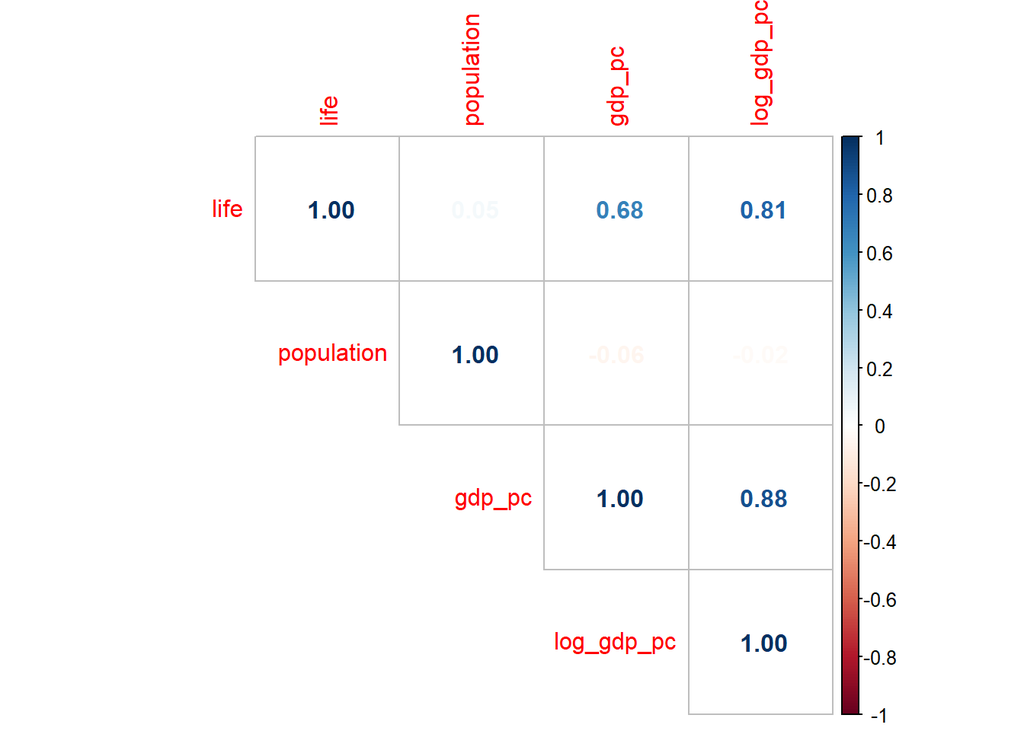

Gapminder 2007 年四个数值变量的 Pearson 相关矩阵

```r
# corrplot 首次使用前需在 Console 中安装
corrplot::corrplot(
  correlation_matrix,
  method = "number",
  type = "upper"
)
```

相关矩阵适合初步发现高度相关的变量组合。它不能替代建模阶段的共线性诊断，也不能说明变量关系在不同组别或时间中保持一致。

**何时可以写入论文**

样本构成、缺失情况、主要变量的描述统计和关键分组比较，常放在论文正文或附录中，用来说明分析样本及变量特征。报告应保留与研究问题有关的结果，无需逐项展示全部探索过程。由 EDA 新产生的分析应标明为探索性分析。

**延伸阅读与函数文档**

- Tukey, J. W. (1977). *Exploratory Data Analysis*. Addison-Wesley.
- [R for Data Science：Exploratory Data Analysis](https://r4ds.had.co.nz/exploratory-data-analysis.html)：以问题、变异和变量关系组织 EDA。
- [skimr 文档](https://docs.ropensci.org/skimr/)：查看 `skim()`、`focus()` 及输出字段。
- [dplyr `summarise()` 文档](https://dplyr.tidyverse.org/reference/summarise.html)：核对分组汇总与 `.groups` 参数。
- [R `cor.test()` 文档](https://stat.ethz.ch/R-manual/R-devel/library/stats/html/cor.test.html)：查阅 Pearson、Spearman 与 Kendall 检验参数。

## **6.0 章节练习与测评**

### **6.0 章节练习与测评**

本节包含三个环节。任务 1 提供可直接运行的模板，需要复制、修改并 Knit；任务 2 以小组为单位制作一份 R Markdown 报告，并在课堂展示本地 HTML；任务 3 通过选择题检查本章知识点。

01**跟随示例**复制、修改并 Knit

02**小组实践与展示**共同制作本地 HTML

03**知识点自测**选择答案并查看解析

#### **任务 1：跟随示例运行**

某社区研究在正式调查前进行了小规模试访，研究人员希望检查不同访谈方式的执行时长和数据记录质量。教学模拟数据中，每行应对应一名受访者的一次完整访谈；`interview_mode` 记录访谈方式，`interview_minutes_text` 记录访谈时长。原始导出包含多余空格、一条因重复导出产生的完全重复记录、“未记录”形式的缺失编码和带单位的数值文本。

建议文件名：`chapter_2_follow_along.Rmd`。

Step 1 **先说明记录含义**  
在报告正文中写明：一行表示一名受访者的一次完整访谈，访谈时长的单位为分钟。随后运行 `glimpse()`，确认三列在清理前都以文本形式保存。

Step 2 **复制并运行完整流程**  
下面的代码会先定位重复编号，再统一文本、转换缺失编码、提取数值并生成分组摘要。代码应按原顺序运行，暂时不要跳过中间检查。

**练习代码：从试访记录到访谈方式摘要**

```r
library(tidyverse)

# 教学模拟数据：一行原本应对应一名受访者的一次完整访谈
interview_raw <- tribble(
  ~respondent_id, ~interview_mode, ~interview_minutes_text,
  "R01", "入户访谈",    "45 分钟",
  "R02", " 社区访谈点", "60分钟",
  "R03", "入户访谈",    "未记录",
  "R04", "线上访谈 ",   "30分钟",
  "R05", "线上访谈",    "35 分钟",
  "R06", "线上访谈",    "120分钟",
  "R06", "线上访谈",    "120分钟",
  "R07", "社区访谈点",  "20分钟",
  "R08", "社区访谈点 ", "25 分钟",
  "R09", "社区访谈点",  "未记录",
  "R10", "入户访谈",    "50分钟"
)

# 1. 检查变量类型和原始记录规模
glimpse(interview_raw)

# 2. 查找出现多次的受访者编号
duplicate_check <- interview_raw %>%
  count(respondent_id, name = "n_records") %>%
  filter(n_records > 1)

duplicate_check

# 3. 统一文本、转换缺失编码并提取分钟数
interview_clean <- interview_raw %>%
  mutate(
    interview_mode = str_squish(interview_mode),
    interview_minutes_text = na_if(interview_minutes_text, "未记录"),
    interview_minutes = parse_number(interview_minutes_text)
  ) %>%
  distinct()

# 4. 按访谈方式报告样本规模、缺失情况和描述统计
mode_summary <- interview_clean %>%
  group_by(interview_mode) %>%
  summarise(
    n_total = n(),
    n_valid = sum(!is.na(interview_minutes)),
    n_missing = sum(is.na(interview_minutes)),
    mean_minutes = mean(interview_minutes, na.rm = TRUE),
    median_minutes = median(interview_minutes, na.rm = TRUE),
    sd_minutes = sd(interview_minutes, na.rm = TRUE),
    iqr_minutes = IQR(interview_minutes, na.rm = TRUE),
    .groups = "drop"
  ) %>%
  mutate(
    across(
      c(mean_minutes, median_minutes, sd_minutes, iqr_minutes),
      function(x) round(x, 1)
    )
  ) %>%
  arrange(desc(median_minutes))

knitr::kable(
  mode_summary,
  col.names = c(
    "访谈方式", "总记录数", "有效记录数", "缺失数",
    "均值", "中位数", "标准差", "四分位距"
  ),
  caption = "不同访谈方式的访谈时长描述统计"
)
```

```
## Rows: 11
## Columns: 3
## $ respondent_id          <chr> "R01", "R02", "R03", "R04", "R05", "R06", "R06"…
## $ interview_mode         <chr> "入户访谈", " 社区访谈点", "入户访谈", "线上访谈 ", "线上访谈", "线上访…
## $ interview_minutes_text <chr> "45 分钟", "60分钟", "未记录", "30分钟", "35 分钟", "120分钟…
```

```
## # A tibble: 1 × 2
##   respondent_id n_records
##   <chr>             <int>
## 1 R06                   2
```

不同访谈方式的访谈时长描述统计

| 访谈方式 | 总记录数 | 有效记录数 | 缺失数 | 均值 | 中位数 | 标准差 | 四分位距 |
| --- | --- | --- | --- | --- | --- | --- | --- |
| 入户访谈 | 3 | 2 | 1 | 47.5 | 47.5 | 3.5 | 2.5 |
| 线上访谈 | 3 | 3 | 0 | 61.7 | 35.0 | 50.6 | 45.0 |
| 社区访谈点 | 4 | 3 | 1 | 35.0 | 25.0 | 21.8 | 20.0 |

Step 3 **核对处理结果**  
原始数据应有 11 行，`duplicate_check` 应指出 `R06` 出现两次，清理后应保留 10 行。每种访谈方式都应满足 `n_total = n_valid + n_missing`。

Step 4 **解释均值与中位数**  
线上访谈的平均时长约为 61.7 分钟，中位数为 35 分钟。报告需要指出 120 分钟这条记录如何影响均值，同时说明这是一份规模很小的试访模拟数据，不能据此判断访谈方式导致了时长差异。

#### **任务 1 完成标志**

- 已说明一行记录、访谈方式和时间单位的含义。
- 已定位重复编号，并确认删除的是完全相同的重复记录。
- 已将“未记录”转换为真正的缺失值，将带单位文本转换为数值。
- 汇总表同时报告总记录数、有效记录数、缺失数、中心位置和离散程度。
- 结果文字描述了数据中观察到的差异及其解释限制。
- `chapter_2_follow_along.Rmd` 可以从空会话 Knit 为 HTML。

#### **任务 2：小组实践与展示**

在 `chapter_2_group_report.Rmd` 中使用 `gapminder`，完成一份可以在浏览器中打开的本地 HTML。正文和代码需要由小组自行组织，本任务不提供可直接拼接的起步代码。

**研究问题**

1952 年至 2007 年，各大洲国家预期寿命的分布发生了怎样的描述性变化？

Step 1 **界定数据与分析单位**  
说明数据的时间范围和变量含义，并写明一行表示“一个国家在一个年份的记录”。将 `lifeExp` 重命名为符合本章规范的 `life_exp`，新建对象、代码块和文件均使用 `snake_case`。

Step 2 **筛选并检查数据质量**  
保留 1952 年和 2007 年，报告筛选后的行数。检查 `country + year` 是否能唯一标识记录，并核对 `life_exp` 的缺失数量。发现重复或缺失时，应先记录检查结果，再决定后续处理。

Step 3 **生成分组摘要**  
按大洲和年份计算国家数、有效记录数、预期寿命均值、中位数和四分位距。将结果整理成一张结构清楚的 HTML 表格，使两年之间的比较容易辨认。处理流程至少应包含筛选、质量检查、分组汇总和排序或重排四类操作。

Step 4 **解释结果并生成网页**  
正文说明一项时间变化、一项洲际差异和一项解释限制。直接按国家记录计算的大洲均值对每个国家赋予相同权重，不能解释为该洲所有居民的平均预期寿命，也不能据此判断大洲差异的原因。完成后重启 R，再从头 Knit 出本地 HTML。

**卡住时查看：函数线索与检查顺序**

- 数据检查可从 `glimpse()` 开始，再根据任务选择 `filter()`、`count()` 和缺失值判断。
- 分组摘要需要先确定分组变量，再考虑 `group_by()`、`summarise()` 与 `arrange()`。
- 五个大洲与两个年份组合后，分组摘要通常有 10 行。若行数不同，应回查筛选条件、分组变量和 key。
- 若希望把 1952 年和 2007 年放在相邻列中，可回看 `pivot_wider()`；转换前先确认每个“大洲 × 年份 × 指标”位置只有一个汇总值。
- `gapminder` 中大洋洲只包含两个国家。解释离散程度时应同时查看组内国家数。

#### **展示要点**

- 研究问题、一行记录的含义及保留的两个年份。
- 数据质量检查结果和分组汇总表的组织方式。
- 一项主要发现，以及均值、中位数或四分位距提供了什么信息。
- 国家层面、等权汇总和描述性比较带来的一项解释限制。

##### **展示前检查**

- `chapter_2_group_report.Rmd` 能从空会话 Knit 为本地 HTML。
- 代码自行读取或创建全部对象，没有依赖 Console 中遗留的结果。
- 文件、对象和代码块使用 `snake_case`，正文没有个人电脑的绝对路径。
- 已说明变量含义、观测单位、时间范围和分组方式。
- 已检查缺失记录、重复 key、总记录数和各组有效记录数。
- 汇总表包含五个大洲与两个年份的组合，标题和列名能够说明表中数值。
- 结果文字区分了观察到的差异、可能解释和当前数据不能支持的结论。

#### **任务 3：知识点自测**

以下六道题围绕数据类型、整洁结构、管道、表连接、缺失值和 EDA 解释设置。选择答案后点击“检查答案”，页面会显示对应解析。

01`interview_minutes_text` 的取值为“45 分钟”“60 分钟”和“未记录”，`glimpse()` 显示该列为 `<chr>`。确认单位为分钟后，哪种处理最合适？ 直接使用 `as.numeric()`，忽略转换结果中的缺失 先把“未记录”转换为 `NA`，再使用 `parse_number()` 并核对结果 把整列转换为因子，再计算平均数

02一张表包含 `city`、`visits_2020` 和 `visits_2021`。若“年份”是分析变量，每行需要表示一条城市年度观测，应怎样理解这张表？ 年份已经是独立变量，无需检查表格结构 应把两个年份的数值相加，保留一列总量 年份值写在列名中，可整理为 `year` 与 `visits` 两列

03运行 `clean_data <- raw_data %>% filter(year == 2007)` 后，哪项表述正确？ `clean_data` 保存筛选结果，`raw_data` 保持不变 `raw_data` 会被永久删去其他年份 两个对象都会自动按年份分组

04右表中的同一个 key 出现多次时，`left_join()` 最可能产生什么结果？ 自动保留右表中的第一条记录 匹配结果的行数可能增加 左表未匹配的记录会被删除

05某组共有 40 条记录，其中 32 条 `score` 有效。使用 `mean(score, na.rm = TRUE)` 后，哪种报告最准确？ 均值使用全部 40 条记录，缺失值被当作 0 8 条缺失记录已经从原数据中永久删除 均值基于 32 条有效记录，同时报告 8 条缺失记录

06使用 2007 年国家记录计算人均 GDP 与预期寿命的相关系数，得到较强正相关。哪项解释合适？ 收入提高必然导致每位居民寿命延长 该结果已经排除了地区、制度和历史条件的影响 2007 年国家层面存在正相关，个人关系与因果机制仍需其他证据

**© 华东师范大学 社会发展学院 人口研究所** | [**DAWN 研究组**](https://dawn-ecnu.github.io) | yzliu@soci.ecnu.edu.cn

课程负责人：刘贇喆 本章作者：刘贇喆

最后更新：2026年10月10日 构建环境：R version 4.6.1 (2026-06-24 ucrt)

[CC BY-NC-SA 4.0](https://creativecommons.org/licenses/by-nc-sa/4.0/deed.zh) 回到顶部